# Multiple Regression

-Purpose - Preprocess Data – Install and Load Libraries – Import Dataset – Missing Data – Data Exploration - What are our variables and what do they mean? — Useful functions for Data Exploration —Product Number — Price — Customer Reviews —- 5-Star Reviews —- 4-Star Reviews —- 3-Star Reviews —- 2-Star Reviews —- 1-Star Reviews — Service Reviews —- Positive Service Reviews —- Negative Service Reviews — Recommend Product — Best Sellers Rank — Shipping Weight — Product Depth — Product Height — Profit Margin — Product Type – Normalize Data – Remove Outliers – Split Data — Normalized Data Set — Data As Is — Data with Outliers Removed - Train Models – Linear Regression Models — Plot of Residuals — R-Squared —

Blackwell Electronics is a fictitious company that sells computers. The sales team has been tracking the sales performance of products and would like us to predict customer brand preference taking into account the type of product. We will look at historical sales data and predict sales volume. We want to understand how types of products might impact sales. There are four different product types that the sales team wants us to primarily focus on: PC, Laptops, Netbooks and Smartphones.

There are 18 variables in this dataset. We will explore all of them but we are primarily focused on sales volume, product type, service reviews, and customer reviews.

# 1 Preprocess Data

## 1.1 Install and Load Libraries

[output not shown]

## 1.2 Read Data

Read existing attributes data file.

```r
existing <- read.csv("existingproductattributes2017.csv", header = TRUE)
```

Read new attributes data file.

```r
new <- read.csv("newproductattributes2017.csv", header = TRUE)
```

### 1.2.1 Useful functions for analysis

```r
# IQR test for outliers
outlier_test <- function(col, data) {
        q1 <- quantile(col,.25)
        q3 <- quantile(col,.75)
        iqr <- IQR(col)
        lower_bound_outlier <- q1[[1]] - 1.5*iqr
        upper_bound_outlier <- q3[[1]] + 1.5*iqr
        df_outliers <- data[col < lower_bound_outlier | col > upper_bound_outlier,]
        return (df_outliers)}
# Add outliers to outlier list
my_outliers <- c()
append_outliers <- function(my_list , df) {
        df_outliers_ProductNum <- df$ProductNum
        my_outliers <- append(my_list, df_outliers_ProductNum)
        return (my_outliers)
}
```

## 1.3 Data Exploration

We will explore all of our variables. We look for missing values, any necessary feature transformations, outliers, and patterns.

In particular, we will create dummy variables for multiple regression.

### 1.3.1 Structure of Data

Review data types.

```r
str(existing)
```

```
'data.frame':   80 obs. of  18 variables:
 $ ProductType          : Factor w/ 12 levels "Accessories",..: 7 7 7 5 5 1 1 1 1 1 ...
 $ ProductNum           : int  101 102 103 104 105 106 107 108 109 110 ...
 $ Price                : num  949 2250 399 410 1080 ...
 $ x5StarReviews        : int  3 2 3 49 58 83 11 33 16 10 ...
 $ x4StarReviews        : int  3 1 0 19 31 30 3 19 9 1 ...
 $ x3StarReviews        : int  2 0 0 8 11 10 0 12 2 1 ...
 $ x2StarReviews        : int  0 0 0 3 7 9 0 5 0 0 ...
 $ x1StarReviews        : int  0 0 0 9 36 40 1 9 2 0 ...
 $ PositiveServiceReview: int  2 1 1 7 7 12 3 5 2 2 ...
 $ NegativeServiceReview: int  0 0 0 8 20 5 0 3 1 0 ...
 $ Recommendproduct     : num  0.9 0.9 0.9 0.8 0.7 0.3 0.9 0.7 0.8 0.9 ...
 $ BestSellersRank      : int  1967 4806 12076 109 268 64 NA 2 NA 18 ...
 $ ShippingWeight       : num  25.8 50 17.4 5.7 7 1.6 7.3 12 1.8 0.75 ...
 $ ProductDepth         : num  23.9 35 10.5 15 12.9 ...
 $ ProductWidth         : num  6.62 31.75 8.3 9.9 0.3 ...
 $ ProductHeight        : num  16.9 19 10.2 1.3 8.9 ...
 $ ProfitMargin         : num  0.15 0.25 0.08 0.08 0.09 0.05 0.05 0.05 0.05 0.05 ...
 $ Volume               : int  12 8 12 196 232 332 44 132 64 40 ...
```

```r
str(new)
```

```
'data.frame':   24 obs. of  18 variables:
 $ ProductType          : Factor w/ 12 levels "Accessories",..: 7 7 5 5 5 6 6 6 6 12 ...
 $ ProductNum           : int  171 172 173 175 176 178 180 181 183 186 ...
 $ Price                : num  699 860 1199 1199 1999 ...
 $ x5StarReviews        : int  96 51 74 7 1 19 312 23 3 296 ...
 $ x4StarReviews        : int  26 11 10 2 1 8 112 18 4 66 ...
 $ x3StarReviews        : int  14 10 3 1 1 4 28 7 0 30 ...
 $ x2StarReviews        : int  14 10 3 1 3 1 31 22 1 21 ...
 $ x1StarReviews        : int  25 21 11 1 0 10 47 18 0 36 ...
 $ PositiveServiceReview: int  12 7 11 2 0 2 28 5 1 28 ...
 $ NegativeServiceReview: int  3 5 5 1 1 4 16 16 0 9 ...
 $ Recommendproduct     : num  0.7 0.6 0.8 0.6 0.3 0.6 0.7 0.4 0.7 0.8 ...
 $ BestSellersRank      : int  2498 490 111 4446 2820 4140 2699 1704 5128 34 ...
 $ ShippingWeight       : num  19.9 27 6.6 13 11.6 5.8 4.6 4.8 4.3 3 ...
 $ ProductDepth         : num  20.63 21.89 8.94 16.3 16.81 ...
 $ ProductWidth         : num  19.2 27 12.8 10.8 10.9 ...
 $ ProductHeight        : num  8.39 9.13 0.68 1.4 0.88 1.2 0.95 1.5 0.97 0.37 ...
 $ ProfitMargin         : num  0.25 0.2 0.1 0.15 0.23 0.08 0.09 0.11 0.09 0.1 ...
 $ Volume               : int  0 0 0 0 0 0 0 0 0 0 ...
```

For multiple regression with categorical variables, we will convert factors to binary values using the dummy variable method. A quick look at the structure of our dataset shows that Product Type is the only factor. Product Number could be considered a categorical variable but we will leave it as it is and just use it as a reference for specific products.

### 1.3.2 Missing Values

```r
summary(existing)
```

```
           ProductType   ProductNum        Price         x5StarReviews    x4StarReviews
 Accessories     :26   Min.   :101.0   Min.   :   3.60   Min.   :   0.0   Min.   :  0.00
 Printer         :12   1st Qu.:120.8   1st Qu.:  52.66   1st Qu.:  10.0   1st Qu.:  2.75
 ExtendedWarranty:10   Median :140.5   Median : 132.72   Median :  50.0   Median : 22.00
 Software        : 6   Mean   :142.6   Mean   : 247.25   Mean   : 176.2   Mean   : 40.20
 Display         : 5   3rd Qu.:160.2   3rd Qu.: 352.49   3rd Qu.: 306.5   3rd Qu.: 33.00
 PC              : 4   Max.   :200.0   Max.   :2249.99   Max.   :2801.0   Max.   :431.00
 (Other)         :17
 x3StarReviews    x2StarReviews    x1StarReviews     PositiveServiceReview
 Min.   :  0.00   Min.   :  0.00   Min.   :   0.00   Min.   :  0.00
 1st Qu.:  2.00   1st Qu.:  1.00   1st Qu.:   2.00   1st Qu.:  2.00
 Median :  7.00   Median :  3.00   Median :   8.50   Median :  5.50
 Mean   : 14.79   Mean   : 13.79   Mean   :  37.67   Mean   : 51.75
 3rd Qu.: 11.25   3rd Qu.:  7.00   3rd Qu.:  15.25   3rd Qu.: 42.00
 Max.   :162.00   Max.   :370.00   Max.   :1654.00   Max.   :536.00

 NegativeServiceReview Recommendproduct BestSellersRank ShippingWeight     ProductDepth
 Min.   :  0.000       Min.   :0.100    Min.   :    1   Min.   : 0.0100   Min.   :  0.000
 1st Qu.:  1.000       1st Qu.:0.700    1st Qu.:    7   1st Qu.: 0.5125   1st Qu.:  4.775
 Median :  3.000       Median :0.800    Median :   27   Median : 2.1000   Median :  7.950
 Mean   :  6.225       Mean   :0.745    Mean   : 1126   Mean   : 9.6681   Mean   : 14.425
 3rd Qu.:  6.250       3rd Qu.:0.900    3rd Qu.:  281   3rd Qu.:11.2050   3rd Qu.: 15.025
 Max.   :112.000       Max.   :1.000    Max.   :17502   Max.   :63.0000   Max.   :300.000
                                        NA's   :15
  ProductWidth    ProductHeight     ProfitMargin        Volume
 Min.   : 0.000   Min.   : 0.000   Min.   :0.0500   Min.   :    0
 1st Qu.: 1.750   1st Qu.: 0.400   1st Qu.:0.0500   1st Qu.:   40
 Median : 6.800   Median : 3.950   Median :0.1200   Median :  200
 Mean   : 7.819   Mean   : 6.259   Mean   :0.1545   Mean   :  705
 3rd Qu.:11.275   3rd Qu.:10.300   3rd Qu.:0.2000   3rd Qu.: 1226
 Max.   :31.750   Max.   :25.800   Max.   :0.4000   Max.   :11204
```

```r
sum(is.na(new))
```

```
[1] 0
```

It looks like there are missing values in the existing attributes dataset, but not in the new attributes dataset. We can handle missing data by either deleting the row, delete the class, delete the BestSellersRank variable, impute it with the mean, median or mode, or predict the BestSellersRank for it. For this analysis, we will simply delete any row with a missing value.

```r
#remove missing values
existing <- na.omit(existing)
# verify removal
str(existing)
```

```
'data.frame':   65 obs. of  18 variables:
 $ ProductType          : Factor w/ 12 levels "Accessories",..: 7 7 7 5 5 1 1 1 1 1 ...
 $ ProductNum           : int  101 102 103 104 105 106 108 110 112 114 ...
 $ Price                : num  949 2250 399 410 1080 ...
 $ x5StarReviews        : int  3 2 3 49 58 83 33 10 75 313 ...
 $ x4StarReviews        : int  3 1 0 19 31 30 19 1 25 62 ...
 $ x3StarReviews        : int  2 0 0 8 11 10 12 1 6 13 ...
 $ x2StarReviews        : int  0 0 0 3 7 9 5 0 3 8 ...
 $ x1StarReviews        : int  0 0 0 9 36 40 9 0 3 16 ...
 $ PositiveServiceReview: int  2 1 1 7 7 12 5 2 9 44 ...
 $ NegativeServiceReview: int  0 0 0 8 20 5 3 0 2 3 ...
 $ Recommendproduct     : num  0.9 0.9 0.9 0.8 0.7 0.3 0.7 0.9 0.2 0.9 ...
 $ BestSellersRank      : int  1967 4806 12076 109 268 64 2 18 7 6 ...
 $ ShippingWeight       : num  25.8 50 17.4 5.7 7 1.6 12 0.75 2.2 0.35 ...
 $ ProductDepth         : num  23.9 35 10.5 15 12.9 ...
 $ ProductWidth         : num  6.62 31.75 8.3 9.9 0.3 ...
 $ ProductHeight        : num  16.9 19 10.2 1.3 8.9 ...
 $ ProfitMargin         : num  0.15 0.25 0.08 0.08 0.09 0.05 0.05 0.05 0.05 0.05 ...
 $ Volume               : int  12 8 12 196 232 332 132 40 300 1252 ...
 - attr(*, "na.action")= 'omit' Named int  7 9 11 13 15 19 21 30 31 42 ...
  ..- attr(*, "names")= chr  "7" "9" "11" "13" ...
```

[output not shown]

This is the sales volume of each product. It is a continous variable inputted as an integer and is also our target variable.

```r
unique_volume <- length(unique(existing$Volume))
unique_volume
```

```
[1] 48
```

```r
summary(existing$Volume)
```

```
   Min. 1st Qu.  Median    Mean 3rd Qu.    Max.
    0.0    52.0   300.0   829.7  1232.0 11204.0
```

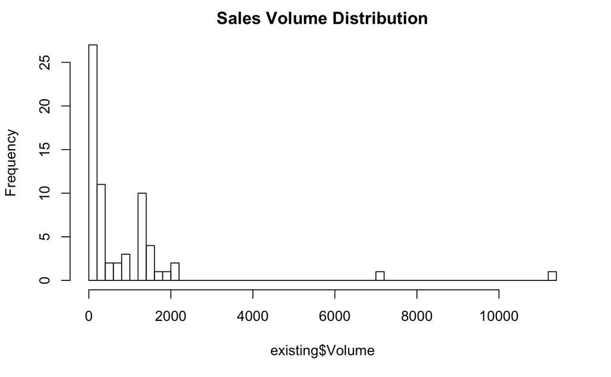

```r
hist(existing$Volume, main = "Sales Volume Distribution", breaks =  unique_volume )
```

https://stats.stackexchange.com/questions/87962/cooks-distance-cut-off-value https://stats.stackexchange.com/questions/164099/removing-outliers-based-on-cooks-distance-in-r-language

Outliers

```r
outlier_test_df <- outlier_test(existing$Volume,existing)
outlier_test_df
```

|  | ProductType | ProductNum | Price | x5StarReviews | x4StarReviews | x3StarReviews | x2StarReviews | x1StarReviews | PositiveServiceReview | NegativeServiceReview | Recommendproduct | BestSellersRank | ShippingWeight | ProductDepth | ProductWidth | ProductHeight | ProfitMargin | Volume |
| --- | --- | --- | --- | --- | --- | --- | --- | --- | --- | --- | --- | --- | --- | --- | --- | --- | --- | --- |
| 50 | Accessories | 150 | 49.99 | 2801 | 431 | 157 | 154 | 270 | 536 | 22 | 0.8 | 30 | 0.40 | 7.0 | 4.5 | 1.20 | 0.05 | 11204 |
| 73 | GameConsole | 198 | 129.00 | 1759 | 296 | 109 | 56 | 44 | 56 | 13 | 0.9 | 215 | 7.25 | 8.5 | 6.0 | 1.75 | 0.18 | 7036 |

```r
my_outliers
```

```r
my_outliers <- append_outliers(my_outliers,outlier_test_df)
my_outliers
```

```
[1] 150 198
```

There are two products that are outliers: product 150 and product 198.

I am not a 100% certain about removing them from the dataset. This outlier could indicate that the attributes of these products are just so good that they can raise sales tremendously. I will train models without these outliers and with the outliers to compare results.

Instances of Zero Volume:

```r
existing[existing$Volume == 0,]
```

|  | ProductType | ProductNum | Price | x5StarReviews | x4StarReviews | x3StarReviews | x2StarReviews | x1StarReviews | PositiveServiceReview | NegativeServiceReview | Recommendproduct | BestSellersRank | ShippingWeight | ProductDepth | ProductWidth | ProductHeight | ProfitMargin | Volume |
| --- | --- | --- | --- | --- | --- | --- | --- | --- | --- | --- | --- | --- | --- | --- | --- | --- | --- | --- |
| 29 | PrinterSupplies | 129 | 83.11 | 0 | 0 | 0 | 1 | 3 | 1 | 1 | 0.1 | 17502 | 10.3 | 0 | 0 | 0 | 0.35 | 0 |
| 32 | ExtendedWarranty | 132 | 79.98 | 0 | 1 | 1 | 1 | 1 | 0 | 3 | 0.4 | 5 | 0.2 | 0 | 0 | 0 | 0.40 | 0 |

These are printer supplies and warranty, which are ancillary products and are not useful for htis analysis.

```r
#remove
existing <- existing[!existing$Volume == 0,]
#verify
existing[existing$Volume == 0,]
```

| ProductType | ProductNum | Price | x5StarReviews | x4StarReviews | x3StarReviews | x2StarReviews | x1StarReviews | PositiveServiceReview | NegativeServiceReview | Recommendproduct | BestSellersRank | ShippingWeight | ProductDepth | ProductWidth | ProductHeight | ProfitMargin | Volume |
| --- | --- | --- | --- | --- | --- | --- | --- | --- | --- | --- | --- | --- | --- | --- | --- | --- | --- |

```r
NA
```

### 1.3.3 ProductNum

ProductNum refers to the unique product number. This is a way to identify a product. It is recorded as a number. Check for duplicates

```r
str(existing$ProductNum)
```

```
 int [1:63] 101 102 103 104 105 106 108 110 112 114 ...
```

```r
length(unique(existing$ProductNum))
```

```
[1] 63
```

There are 63 instances and 63 unique values, indicating that there are no duplicates.

### 1.3.4 Price

```r
unique_volume <- length(unique(existing$Price))
unique_volume # 58 unique values
```

```
[1] 58
```

```r
summary(existing$Price) # integer
```

```
   Min. 1st Qu.  Median    Mean 3rd Qu.    Max.
   3.60   58.49  141.95  273.21  369.99 2249.99
```

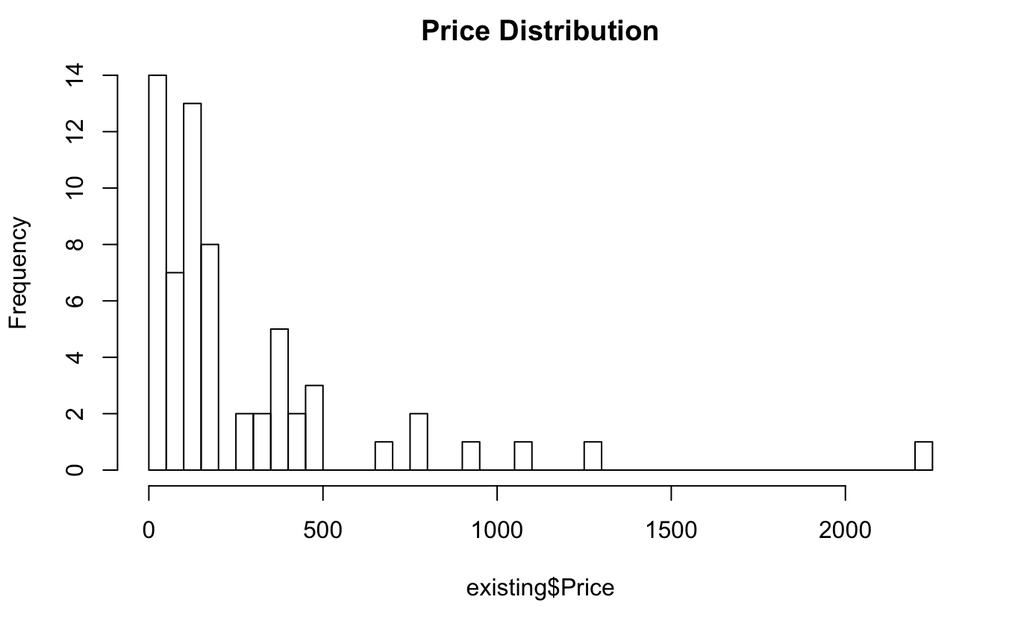

```r
hist(existing$Price, main = "Price Distribution", breaks =  58 )
```

```r
table(existing$Price)
```

```
    3.6    3.84    6.99   10.75      15   16.24   16.99   19.99   21.08   31.99   38.66
      2       1       1       1       1       1       1       1       1       1       1
   48.5   49.99   52.72   56.99   59.99   65.29      69   87.98      99  103.85  114.22
      1       1       1       1       1       1       1       1       1       1       1
 124.98  124.99  126.95  128.49     129  129.98  129.99  134.98  141.95  149.99  151.98
      1       1       1       1       1       1       1       1       1       2       1
 169.98  174.99  179.98  179.99   189.5     199     200  262.98  299.99  349.99  359.99
      1       1       1       1       1       1       1       1       1       2       1
 379.99     395  396.35     399  409.99     419     499     670   770.6  783.98     949
      1       1       1       1       1       1       3       1       1       1       1
1079.99 1276.57 2249.99
      1       1       1
```

There’s a very pricy item. I wander if it is related to the outliers found in sales volume.

```r
existing[existing$Price == 2249.99 | existing$Price ==1276.57 ,]
```

|  | ProductType | ProductNum | Price | x5StarReviews | x4StarReviews | x3StarReviews | x2StarReviews | x1StarReviews | PositiveServiceReview | NegativeServiceReview | Recommendproduct | BestSellersRank | ShippingWeight | ProductDepth | ProductWidth | ProductHeight | ProfitMargin | Volume |
| --- | --- | --- | --- | --- | --- | --- | --- | --- | --- | --- | --- | --- | --- | --- | --- | --- | --- | --- |
| 2 | PC | 102 | 2249.99 | 2 | 1 | 0 | 0 | 0 | 1 | 0 | 0.9 | 4806 | 50 | 35.0 | 31.75 | 19.0 | 0.25 | 8 |
| 57 | Display | 157 | 1276.57 | 164 | 33 | 6 | 13 | 6 | 12 | 4 | 0.9 | 8 | 23 | 15.5 | 17.70 | 5.7 | 0.25 | 656 |

Nope. The sales volume for these products are not in the outier range.

Outliers

```r
outlier_test_df <- outlier_test(existing$Price,existing)
outlier_test_df
```

|  | ProductType | ProductNum | Price | x5StarReviews | x4StarReviews | x3StarReviews | x2StarReviews | x1StarReviews | PositiveServiceReview | NegativeServiceReview | Recommendproduct | BestSellersRank | ShippingWeight | ProductDepth | ProductWidth | ProductHeight | ProfitMargin | Volume |
| --- | --- | --- | --- | --- | --- | --- | --- | --- | --- | --- | --- | --- | --- | --- | --- | --- | --- | --- |
| 1 | PC | 101 | 949.00 | 3 | 3 | 2 | 0 | 0 | 2 | 0 | 0.9 | 1967 | 25.8 | 23.94 | 6.62 | 16.89 | 0.15 | 12 |
| 2 | PC | 102 | 2249.99 | 2 | 1 | 0 | 0 | 0 | 1 | 0 | 0.9 | 4806 | 50.0 | 35.00 | 31.75 | 19.00 | 0.25 | 8 |
| 5 | Laptop | 105 | 1079.99 | 58 | 31 | 11 | 7 | 36 | 7 | 20 | 0.7 | 268 | 7.0 | 12.90 | 0.30 | 8.90 | 0.09 | 232 |
| 57 | Display | 157 | 1276.57 | 164 | 33 | 6 | 13 | 6 | 12 | 4 | 0.9 | 8 | 23.0 | 15.50 | 17.70 | 5.70 | 0.25 | 656 |

```r
my_outliers
```

```
[1] 150 198
```

```r
my_outliers <- append_outliers(my_outliers,outlier_test_df)
my_outliers
```

```
[1] 150 198 101 102 105 157
```

### 1.3.5 5 Star Reviews

```r
unique_volume <- length(unique(existing$x5StarReviews))
unique_volume # 58 unique values
```

```
[1] 47
```

```r
summary(existing$x5StarReviews) # integer
```

```
   Min. 1st Qu.  Median    Mean 3rd Qu.    Max.
      1      19      77     214     308    2801
```

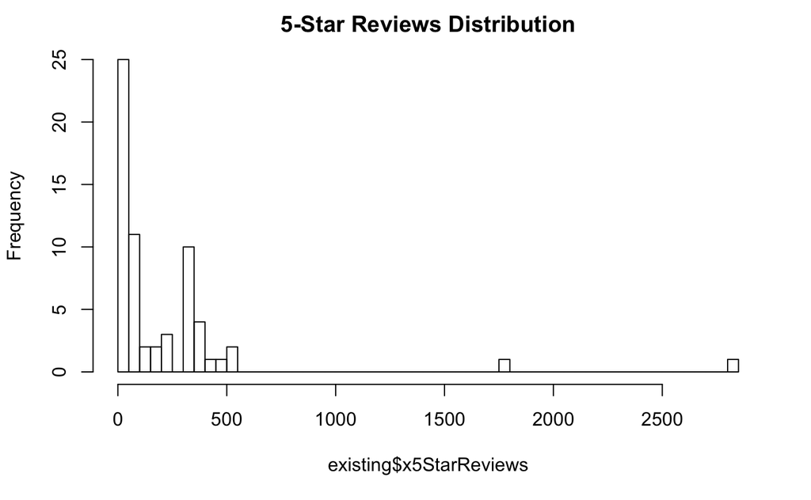

```r
hist(existing$x5StarReviews, main = "5-Star Reviews Distribution", breaks =  58 )
```

```r
table(existing$x5StarReviews)
```

```
   1    2    3    4    5    8   10   11   13   18   20   21   22   26   29   33   49   51
   1    1    4    2    1    3    1    1    1    1    1    1    3    1    1    1    1    1
  58   62   74   75   77   83   86   90   92  108  148  164  170  206  209  226  306  308
   2    1    1    1    1    1    1    1    1    1    1    1    1    1    1    1    1    8
 313  366  368  384  394  421  474  513  535 1759 2801
   1    1    1    1    1    1    1    1    1    1    1
```

Outliers

```r
outlier_test_df <- outlier_test(existing$x5StarReviews,existing)
outlier_test_df
```

|  | ProductType | ProductNum | Price | x5StarReviews | x4StarReviews | x3StarReviews | x2StarReviews | x1StarReviews | PositiveServiceReview | NegativeServiceReview | Recommendproduct | BestSellersRank | ShippingWeight | ProductDepth | ProductWidth | ProductHeight | ProfitMargin | Volume |
| --- | --- | --- | --- | --- | --- | --- | --- | --- | --- | --- | --- | --- | --- | --- | --- | --- | --- | --- |
| 50 | Accessories | 150 | 49.99 | 2801 | 431 | 157 | 154 | 270 | 536 | 22 | 0.8 | 30 | 0.40 | 7.0 | 4.5 | 1.20 | 0.05 | 11204 |
| 73 | GameConsole | 198 | 129.00 | 1759 | 296 | 109 | 56 | 44 | 56 | 13 | 0.9 | 215 | 7.25 | 8.5 | 6.0 | 1.75 | 0.18 | 7036 |

```r
my_outliers
```

```
[1] 150 198 101 102 105 157
```

```r
my_outliers <- append_outliers(my_outliers,outlier_test_df)
my_outliers
```

```
[1] 150 198 101 102 105 157 150 198
```

Looking at my_outliers shows that the products with really high 5-star reviews, also had really high sales volume. This makes logical sense.

We will need to look at the correlation.

### 1.3.6 4 Star Reviews

```r
unique_volume <- length(unique(existing$x4StarReviews))
unique_volume # 37 unique values
```

```
[1] 37
```

```r
summary(existing$x4StarReviews) # integer
```

```
   Min. 1st Qu.  Median    Mean 3rd Qu.    Max.
   0.00    7.00   27.00   47.29   37.50  431.00
```

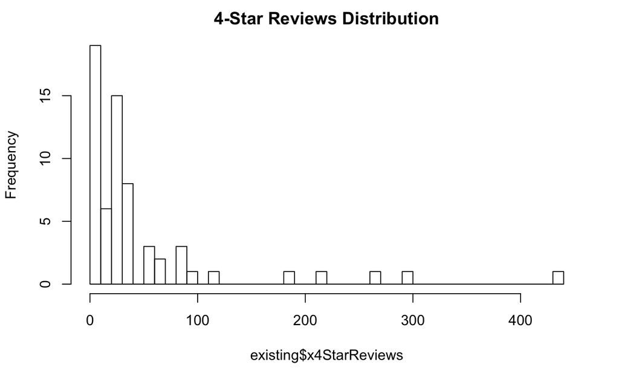

```r
hist(existing$x4StarReviews, main = "4-Star Reviews Distribution", breaks =  37 )
```

```r
table(existing$x4StarReviews)
```

```
  0   1   2   3   5   6   8  10  13  14  17  18  19  25  27  28  29  30  31  33  37  38  51
  7   4   2   1   1   1   1   2   1   1   1   1   2   3   9   1   1   1   3   3   1   1   1
 54  59  62  66  83  87  89 100 114 187 217 261 296 431
  1   1   1   1   1   1   1   1   1   1   1   1   1   1
```

Outliers

```r
outlier_test_df <- outlier_test(existing$x4StarReviews,existing)
outlier_test_df
```

|  | ProductType | ProductNum | Price | x5StarReviews | x4StarReviews | x3StarReviews | x2StarReviews | x1StarReviews | PositiveServiceReview | NegativeServiceReview | Recommendproduct | BestSellersRank | ShippingWeight | ProductDepth | ProductWidth | ProductHeight | ProfitMargin | Volume |
| --- | --- | --- | --- | --- | --- | --- | --- | --- | --- | --- | --- | --- | --- | --- | --- | --- | --- | --- |
| 18 | Accessories | 118 | 174.99 | 170 | 100 | 23 | 20 | 20 | 310 | 6 | 0.8 | 1 | 1.40 | 13.8 | 8.2 | 0.40 | 0.05 | 680 |
| 22 | Software | 122 | 124.99 | 394 | 187 | 63 | 42 | 86 | 55 | 38 | 0.8 | 1 | 0.15 | 7.6 | 5.5 | 1.20 | 0.20 | 1576 |
| 23 | Software | 123 | 56.99 | 513 | 217 | 162 | 370 | 1654 | 144 | 112 | 0.3 | 398 | 0.55 | 5.2 | 1.4 | 7.50 | 0.15 | 2052 |
| 26 | Display | 126 | 179.99 | 306 | 114 | 25 | 22 | 28 | 42 | 12 | 0.8 | 2 | 13.70 | 8.5 | 22.3 | 17.50 | 0.08 | 1224 |
| 48 | Accessories | 148 | 10.75 | 535 | 261 | 134 | 104 | 177 | 120 | 15 | 0.7 | 3 | 1.50 | 11.5 | 20.0 | 7.20 | 0.05 | 2140 |
| 50 | Accessories | 150 | 49.99 | 2801 | 431 | 157 | 154 | 270 | 536 | 22 | 0.8 | 30 | 0.40 | 7.0 | 4.5 | 1.20 | 0.05 | 11204 |
| 67 | Printer | 167 | 149.99 | 206 | 89 | 20 | 22 | 65 | 42 | 50 | 0.7 | 10 | 13.00 | 8.8 | 13.7 | 7.60 | 0.15 | 824 |
| 73 | GameConsole | 198 | 129.00 | 1759 | 296 | 109 | 56 | 44 | 56 | 13 | 0.9 | 215 | 7.25 | 8.5 | 6.0 | 1.75 | 0.18 | 7036 |
| 80 | GameConsole | 200 | 299.99 | 421 | 87 | 20 | 14 | 39 | 29 | 14 | 0.9 | 352 | 10.94 | 12.0 | 11.5 | 7.25 | 0.12 | 1684 |

```r
my_outliers
```

```
[1] 150 198 101 102 105 157 150 198
```

```r
my_outliers <- append_outliers(my_outliers,outlier_test_df)
my_outliers
```

```
 [1] 150 198 101 102 105 157 150 198 118 122 123 126 148 150 167 198 200
```

This outlier list is really long. I will need to remove duplicates and perhaps consider products that are duplicates to really be considered as outliers.

### 1.3.7 3 Star Reviews

```r
unique_volume <- length(unique(existing$x3StarReviews))
unique_volume # 24 unique values
```

```
[1] 24
```

```r
summary(existing$x3StarReviews) # integer
```

```
   Min. 1st Qu.  Median    Mean 3rd Qu.    Max.
   0.00    3.00    8.00   17.59   12.50  162.00
```

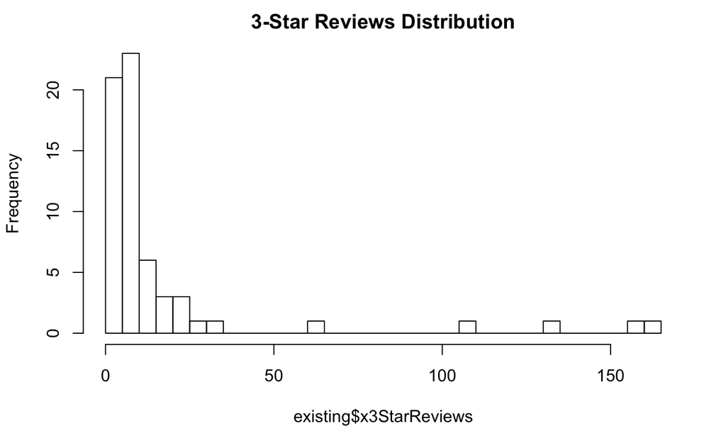

```r
hist(existing$x3StarReviews, main = "3-Star Reviews Distribution", breaks =  unique_volume )
```

```r
table(existing$x3StarReviews)
```

```
  0   1   2   3   4   6   7   8  10  11  12  13  14  17  20  23  25  30  35  63 109 134 157
  6   4   4   5   2   4   4  11   4   1   2   2   1   1   2   2   1   1   1   1   1   1   1
162
  1
```

Outliers

```r
outlier_test_df <- outlier_test(existing$x3StarReviews,existing)
outlier_test_df
```

|  | ProductType | ProductNum | Price | x5StarReviews | x4StarReviews | x3StarReviews | x2StarReviews | x1StarReviews | PositiveServiceReview | NegativeServiceReview | Recommendproduct | BestSellersRank | ShippingWeight | ProductDepth | ProductWidth | ProductHeight | ProfitMargin | Volume |
| --- | --- | --- | --- | --- | --- | --- | --- | --- | --- | --- | --- | --- | --- | --- | --- | --- | --- | --- |
| 22 | Software | 122 | 124.99 | 394 | 187 | 63 | 42 | 86 | 55 | 38 | 0.8 | 1 | 0.15 | 7.6 | 5.5 | 1.20 | 0.20 | 1576 |
| 23 | Software | 123 | 56.99 | 513 | 217 | 162 | 370 | 1654 | 144 | 112 | 0.3 | 398 | 0.55 | 5.2 | 1.4 | 7.50 | 0.15 | 2052 |
| 47 | Accessories | 147 | 38.66 | 209 | 83 | 35 | 38 | 36 | 15 | 4 | 0.7 | 11 | 0.40 | 3.6 | 6.5 | 8.80 | 0.05 | 836 |
| 48 | Accessories | 148 | 10.75 | 535 | 261 | 134 | 104 | 177 | 120 | 15 | 0.7 | 3 | 1.50 | 11.5 | 20.0 | 7.20 | 0.05 | 2140 |
| 50 | Accessories | 150 | 49.99 | 2801 | 431 | 157 | 154 | 270 | 536 | 22 | 0.8 | 30 | 0.40 | 7.0 | 4.5 | 1.20 | 0.05 | 11204 |
| 71 | Tablet | 185 | 499.00 | 148 | 66 | 30 | 20 | 29 | 12 | 6 | 0.8 | 134 | 2.20 | 7.1 | 10.4 | 0.30 | 0.13 | 592 |
| 73 | GameConsole | 198 | 129.00 | 1759 | 296 | 109 | 56 | 44 | 56 | 13 | 0.9 | 215 | 7.25 | 8.5 | 6.0 | 1.75 | 0.18 | 7036 |

```r
my_outliers
```

```
 [1] 150 198 101 102 105 157 150 198 118 122 123 126 148 150 167 198 200
```

```r
my_outliers <- append_outliers(my_outliers,outlier_test_df)
my_outliers
```

```
 [1] 150 198 101 102 105 157 150 198 118 122 123 126 148 150 167 198 200 122 123 147 148 150
[23] 185 198
```

### 1.3.8 2 Star Reviews

```r
unique_volume <- length(unique(existing$x2StarReviews))
unique_volume # 24 unique values
```

```
[1] 24
```

```r
summary(existing$x2StarReviews) # integer
```

```
   Min. 1st Qu.  Median    Mean 3rd Qu.    Max.
   0.00    2.00    3.00   16.95    9.50  370.00
```

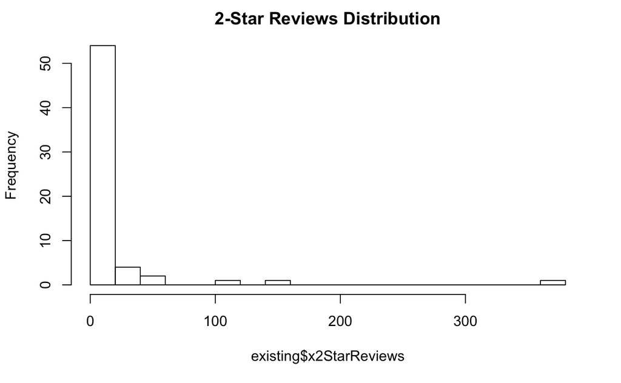

```r
hist(existing$x2StarReviews, main = "2-Star Reviews Distribution", breaks =  unique_volume )
```

```r
table(existing$x2StarReviews)
```

```
  0   1   2   3   4   5   6   7   8   9  10  11  12  13  14  20  22  26  38  42  56 104 154
 10   4   8  12   2   4   2   3   1   1   1   1   1   1   1   2   2   1   1   1   1   1   1
370
  1
```

Outliers

```r
outlier_test_df <- outlier_test(existing$x2StarReviews,existing)
outlier_test_df
```

|  | ProductType | ProductNum | Price | x5StarReviews | x4StarReviews | x3StarReviews | x2StarReviews | x1StarReviews | PositiveServiceReview | NegativeServiceReview | Recommendproduct | BestSellersRank | ShippingWeight | ProductDepth | ProductWidth | ProductHeight | ProfitMargin | Volume |
| --- | --- | --- | --- | --- | --- | --- | --- | --- | --- | --- | --- | --- | --- | --- | --- | --- | --- | --- |
| 22 | Software | 122 | 124.99 | 394 | 187 | 63 | 42 | 86 | 55 | 38 | 0.8 | 1 | 0.15 | 7.6 | 5.5 | 1.20 | 0.20 | 1576 |
| 23 | Software | 123 | 56.99 | 513 | 217 | 162 | 370 | 1654 | 144 | 112 | 0.3 | 398 | 0.55 | 5.2 | 1.4 | 7.50 | 0.15 | 2052 |
| 26 | Display | 126 | 179.99 | 306 | 114 | 25 | 22 | 28 | 42 | 12 | 0.8 | 2 | 13.70 | 8.5 | 22.3 | 17.50 | 0.08 | 1224 |
| 46 | Accessories | 146 | 59.99 | 366 | 59 | 23 | 26 | 24 | 60 | 5 | 0.8 | 22 | 2.40 | 7.9 | 1.4 | 19.10 | 0.05 | 1464 |
| 47 | Accessories | 147 | 38.66 | 209 | 83 | 35 | 38 | 36 | 15 | 4 | 0.7 | 11 | 0.40 | 3.6 | 6.5 | 8.80 | 0.05 | 836 |
| 48 | Accessories | 148 | 10.75 | 535 | 261 | 134 | 104 | 177 | 120 | 15 | 0.7 | 3 | 1.50 | 11.5 | 20.0 | 7.20 | 0.05 | 2140 |
| 50 | Accessories | 150 | 49.99 | 2801 | 431 | 157 | 154 | 270 | 536 | 22 | 0.8 | 30 | 0.40 | 7.0 | 4.5 | 1.20 | 0.05 | 11204 |
| 67 | Printer | 167 | 149.99 | 206 | 89 | 20 | 22 | 65 | 42 | 50 | 0.7 | 10 | 13.00 | 8.8 | 13.7 | 7.60 | 0.15 | 824 |
| 73 | GameConsole | 198 | 129.00 | 1759 | 296 | 109 | 56 | 44 | 56 | 13 | 0.9 | 215 | 7.25 | 8.5 | 6.0 | 1.75 | 0.18 | 7036 |

```r
my_outliers
```

```
 [1] 150 198 101 102 105 157 150 198 118 122 123 126 148 150 167 198 200 122 123 147 148 150
[23] 185 198
```

```r
my_outliers <- append_outliers(my_outliers,outlier_test_df)
my_outliers
```

```
 [1] 150 198 101 102 105 157 150 198 118 122 123 126 148 150 167 198 200 122 123 147 148 150
[23] 185 198 122 123 126 146 147 148 150 167 198
```

### 1.3.9 1 Star Reviews

```r
unique_volume <- length(unique(existing$x1StarReviews))
unique_volume # 24 unique values
```

```
[1] 27
```

```r
summary(existing$x1StarReviews) # integer
```

```
   Min. 1st Qu.  Median    Mean 3rd Qu.    Max.
   0.00    3.00    9.00   46.29   18.00 1654.00
```

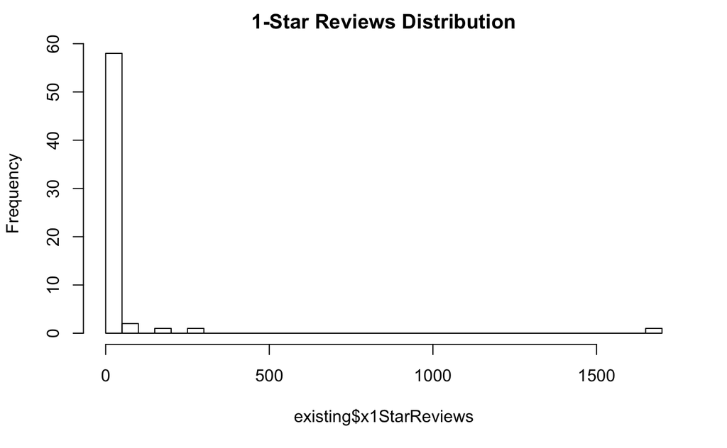

```r
hist(existing$x1StarReviews, main = "1-Star Reviews Distribution", breaks =  unique_volume )
```

```r
table(existing$x1StarReviews)
```

```
   0    1    2    3    4    5    6    8    9   10   12   15   16   20   23   24   28   29
   7    3    4    3    4    1    4    2    4    2    3    8    2    2    1    1    1    1
  36   39   40   44   65   86  177  270 1654
   2    1    1    1    1    1    1    1    1
```

I suppose it’s a good thing that the lower star reviews are less. I’m curious which product has a lot of 1-star reviews. Is it because it’s a bad product or is it because that product has in particularly high sales

Outliers

```r
outlier_test_df <- outlier_test(existing$x1StarReviews,existing)
outlier_test_df
```

|  | ProductType | ProductNum | Price | x5StarReviews | x4StarReviews | x3StarReviews | x2StarReviews | x1StarReviews | PositiveServiceReview | NegativeServiceReview | Recommendproduct | BestSellersRank | ShippingWeight | ProductDepth | ProductWidth | ProductHeight | ProfitMargin | Volume |
| --- | --- | --- | --- | --- | --- | --- | --- | --- | --- | --- | --- | --- | --- | --- | --- | --- | --- | --- |
| 22 | Software | 122 | 124.99 | 394 | 187 | 63 | 42 | 86 | 55 | 38 | 0.8 | 1 | 0.15 | 7.6 | 5.5 | 1.20 | 0.20 | 1576 |
| 23 | Software | 123 | 56.99 | 513 | 217 | 162 | 370 | 1654 | 144 | 112 | 0.3 | 398 | 0.55 | 5.2 | 1.4 | 7.50 | 0.15 | 2052 |
| 48 | Accessories | 148 | 10.75 | 535 | 261 | 134 | 104 | 177 | 120 | 15 | 0.7 | 3 | 1.50 | 11.5 | 20.0 | 7.20 | 0.05 | 2140 |
| 50 | Accessories | 150 | 49.99 | 2801 | 431 | 157 | 154 | 270 | 536 | 22 | 0.8 | 30 | 0.40 | 7.0 | 4.5 | 1.20 | 0.05 | 11204 |
| 67 | Printer | 167 | 149.99 | 206 | 89 | 20 | 22 | 65 | 42 | 50 | 0.7 | 10 | 13.00 | 8.8 | 13.7 | 7.60 | 0.15 | 824 |
| 73 | GameConsole | 198 | 129.00 | 1759 | 296 | 109 | 56 | 44 | 56 | 13 | 0.9 | 215 | 7.25 | 8.5 | 6.0 | 1.75 | 0.18 | 7036 |

```r
my_outliers
```

```
 [1] 150 198 101 102 105 157 150 198 118 122 123 126 148 150 167 198 200 122 123 147 148 150
[23] 185 198 122 123 126 146 147 148 150 167 198
```

```r
my_outliers <- append_outliers(my_outliers,outlier_test_df)
my_outliers
```

```
 [1] 150 198 101 102 105 157 150 198 118 122 123 126 148 150 167 198 200 122 123 147 148 150
[23] 185 198 122 123 126 146 147 148 150 167 198 122 123 148 150 167 198
```

### 1.3.10 Positive Service Reviews

```r
unique_volume <- length(unique(existing$PositiveServiceReview))
unique_volume # 24 unique values
```

```
[1] 27
```

```r
summary(existing$PositiveServiceReview) # integer
```

```
   Min. 1st Qu.  Median    Mean 3rd Qu.    Max.
   0.00    4.00    7.00   64.21   52.50  536.00
```

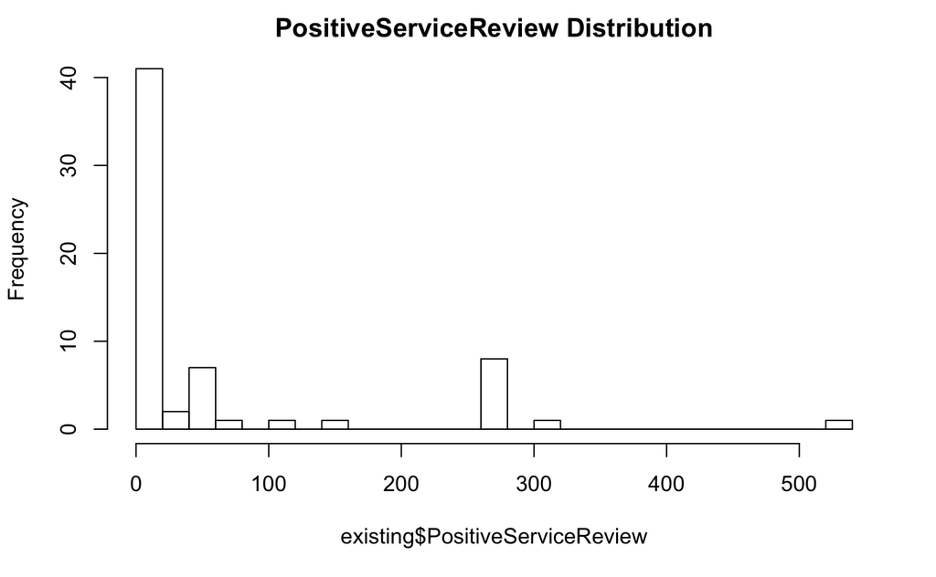

```r
hist(existing$PositiveServiceReview, main = "PositiveServiceReview Distribution", breaks =  unique_volume )
```

```r
table(existing$PositiveServiceReview)
```

```
  0   1   2   3   4   5   6   7   9  12  13  14  15  22  29  42  44  50  55  56  60  80 120
  6   5   2   2   5   5   2   5   2   4   1   1   1   1   1   2   1   1   1   1   1   1   1
144 280 310 536
  1   8   1   1
```

Outliers

```r
outlier_test_df <- outlier_test(existing$PositiveServiceReview,existing)
outlier_test_df
```

|  | ProductType | ProductNum | Price | x5StarReviews | x4StarReviews | x3StarReviews | x2StarReviews | x1StarReviews | PositiveServiceReview | NegativeServiceReview | Recommendproduct | BestSellersRank | ShippingWeight | ProductDepth | ProductWidth | ProductHeight | ProfitMargin | Volume |
| --- | --- | --- | --- | --- | --- | --- | --- | --- | --- | --- | --- | --- | --- | --- | --- | --- | --- | --- |
| 18 | Accessories | 118 | 174.99 | 170 | 100 | 23 | 20 | 20 | 310 | 6 | 0.8 | 1 | 1.40 | 13.8 | 8.2 | 0.4 | 0.05 | 680 |
| 23 | Software | 123 | 56.99 | 513 | 217 | 162 | 370 | 1654 | 144 | 112 | 0.3 | 398 | 0.55 | 5.2 | 1.4 | 7.5 | 0.15 | 2052 |
| 34 | ExtendedWarranty | 134 | 124.98 | 308 | 27 | 8 | 3 | 15 | 280 | 8 | 0.9 | 16 | 0.20 | 0.0 | 0.0 | 0.0 | 0.40 | 1232 |
| 35 | ExtendedWarranty | 135 | 129.98 | 308 | 27 | 8 | 3 | 15 | 280 | 8 | 0.9 | 7 | 0.20 | 0.0 | 0.0 | 0.0 | 0.40 | 1232 |
| 36 | ExtendedWarranty | 136 | 134.98 | 308 | 27 | 8 | 3 | 15 | 280 | 8 | 0.9 | 7 | 0.20 | 0.0 | 0.0 | 0.0 | 0.40 | 1232 |
| 37 | ExtendedWarranty | 137 | 151.98 | 308 | 27 | 8 | 3 | 15 | 280 | 8 | 0.9 | 7 | 0.20 | 0.0 | 0.0 | 0.0 | 0.40 | 1232 |
| 38 | ExtendedWarranty | 138 | 169.98 | 308 | 27 | 8 | 3 | 15 | 280 | 8 | 0.9 | 7 | 0.20 | 0.0 | 0.0 | 0.0 | 0.40 | 1232 |
| 39 | ExtendedWarranty | 139 | 179.98 | 308 | 27 | 8 | 3 | 15 | 280 | 8 | 0.9 | 7 | 0.20 | 0.0 | 0.0 | 0.0 | 0.40 | 1232 |
| 40 | ExtendedWarranty | 140 | 189.50 | 308 | 27 | 8 | 3 | 15 | 280 | 8 | 0.9 | 7 | 0.20 | 0.0 | 0.0 | 0.0 | 0.40 | 1232 |
| 41 | ExtendedWarranty | 141 | 349.99 | 308 | 27 | 8 | 3 | 15 | 280 | 8 | 0.9 | 7 | 0.20 | 0.0 | 0.0 | 0.0 | 0.40 | 1232 |

[output cut: 1 more lines]

```r
my_outliers
```

```
 [1] 150 198 101 102 105 157 150 198 118 122 123 126 148 150 167 198 200 122 123 147 148 150
[23] 185 198 122 123 126 146 147 148 150 167 198 122 123 148 150 167 198
```

```r
my_outliers <- append_outliers(my_outliers,outlier_test_df)
my_outliers
```

```
 [1] 150 198 101 102 105 157 150 198 118 122 123 126 148 150 167 198 200 122 123 147 148 150
[23] 185 198 122 123 126 146 147 148 150 167 198 122 123 148 150 167 198 118 123 134 135 136
[45] 137 138 139 140 141 150
```

### 1.3.11 Negative Service Reviews

```r
unique_volume <- length(unique(existing$NegativeServiceReview))
unique_volume # 24 unique values
```

```
[1] 17
```

```r
summary(existing$NegativeServiceReview) # integer
```

```
   Min. 1st Qu.  Median    Mean 3rd Qu.    Max.
  0.000   1.000   3.000   7.302   8.000 112.000
```

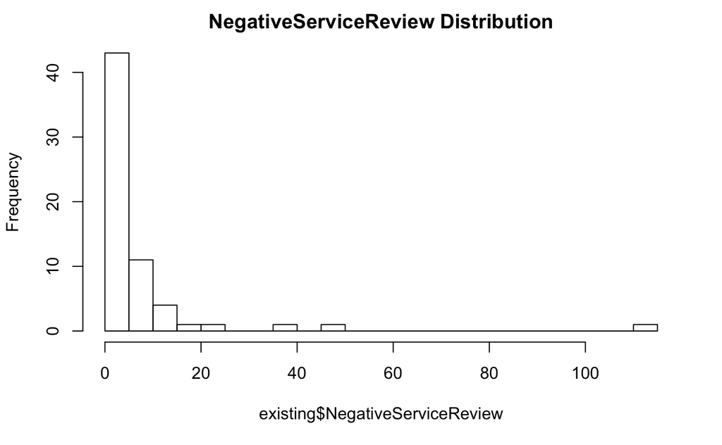

```r
hist(existing$NegativeServiceReview, main = "NegativeServiceReview Distribution", breaks =  unique_volume )
```

```r
table(existing$NegativeServiceReview)
```

```
  0   1   2   3   4   5   6   8  12  13  14  15  20  22  38  50 112
 10  10   8   9   3   3   2   9   1   1   1   1   1   1   1   1   1
```

Outliers

```r
outlier_test_df <- outlier_test(existing$NegativeServiceReview,existing)
outlier_test_df
```

|  | ProductType | ProductNum | Price | x5StarReviews | x4StarReviews | x3StarReviews | x2StarReviews | x1StarReviews | PositiveServiceReview | NegativeServiceReview | Recommendproduct | BestSellersRank | ShippingWeight | ProductDepth | ProductWidth | ProductHeight | ProfitMargin | Volume |
| --- | --- | --- | --- | --- | --- | --- | --- | --- | --- | --- | --- | --- | --- | --- | --- | --- | --- | --- |
| 5 | Laptop | 105 | 1079.99 | 58 | 31 | 11 | 7 | 36 | 7 | 20 | 0.7 | 268 | 7.00 | 12.9 | 0.3 | 8.9 | 0.09 | 232 |
| 22 | Software | 122 | 124.99 | 394 | 187 | 63 | 42 | 86 | 55 | 38 | 0.8 | 1 | 0.15 | 7.6 | 5.5 | 1.2 | 0.20 | 1576 |
| 23 | Software | 123 | 56.99 | 513 | 217 | 162 | 370 | 1654 | 144 | 112 | 0.3 | 398 | 0.55 | 5.2 | 1.4 | 7.5 | 0.15 | 2052 |
| 50 | Accessories | 150 | 49.99 | 2801 | 431 | 157 | 154 | 270 | 536 | 22 | 0.8 | 30 | 0.40 | 7.0 | 4.5 | 1.2 | 0.05 | 11204 |
| 67 | Printer | 167 | 149.99 | 206 | 89 | 20 | 22 | 65 | 42 | 50 | 0.7 | 10 | 13.00 | 8.8 | 13.7 | 7.6 | 0.15 | 824 |

```r
my_outliers
```

```
 [1] 150 198 101 102 105 157 150 198 118 122 123 126 148 150 167 198 200 122 123 147 148 150
[23] 185 198 122 123 126 146 147 148 150 167 198 122 123 148 150 167 198 118 123 134 135 136
[45] 137 138 139 140 141 150
```

```r
my_outliers <- append_outliers(my_outliers,outlier_test_df)
my_outliers
```

```
 [1] 150 198 101 102 105 157 150 198 118 122 123 126 148 150 167 198 200 122 123 147 148 150
[23] 185 198 122 123 126 146 147 148 150 167 198 122 123 148 150 167 198 118 123 134 135 136
[45] 137 138 139 140 141 150 105 122 123 150 167
```

### 1.3.12 Recommend Product

```r
unique_volume <- length(unique(existing$Recommendproduct))
unique_volume # 24 unique values
```

```
[1] 7
```

```r
summary(existing$Recommendproduct) # integer
```

```
   Min. 1st Qu.  Median    Mean 3rd Qu.    Max.
 0.2000  0.7000  0.8000  0.7619  0.9000  0.9000
```

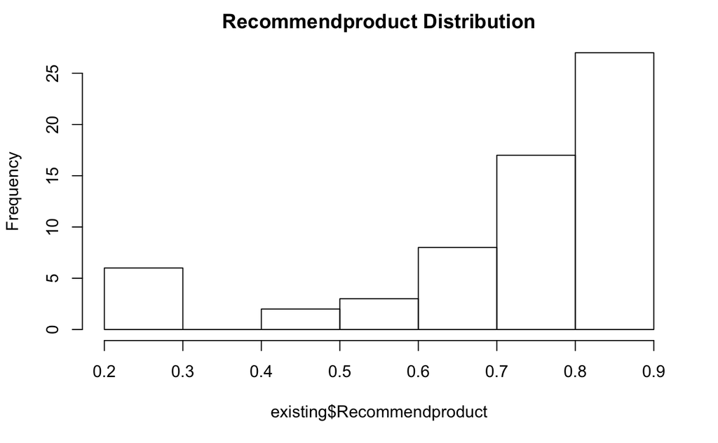

```r
hist(existing$Recommendproduct, main = "Recommendproduct Distribution", breaks =  unique_volume )
```

```r
table(existing$Recommendproduct)
```

```
0.2 0.3 0.5 0.6 0.7 0.8 0.9
  1   5   2   3   8  17  27
```

Outliers

```r
outlier_test_df <- outlier_test(existing$Recommendproduct,existing)
outlier_test_df
```

|  | ProductType | ProductNum | Price | x5StarReviews | x4StarReviews | x3StarReviews | x2StarReviews | x1StarReviews | PositiveServiceReview | NegativeServiceReview | Recommendproduct | BestSellersRank | ShippingWeight | ProductDepth | ProductWidth | ProductHeight | ProfitMargin | Volume |
| --- | --- | --- | --- | --- | --- | --- | --- | --- | --- | --- | --- | --- | --- | --- | --- | --- | --- | --- |
| 6 | Accessories | 106 | 114.22 | 83 | 30 | 10 | 9 | 40 | 12 | 5 | 0.3 | 64 | 1.60 | 5.80 | 4.00 | 1.00 | 0.05 | 332 |
| 12 | Accessories | 112 | 15.00 | 75 | 25 | 6 | 3 | 3 | 9 | 2 | 0.2 | 7 | 2.20 | 21.30 | 1.80 | 7.80 | 0.05 | 300 |
| 23 | Software | 123 | 56.99 | 513 | 217 | 162 | 370 | 1654 | 144 | 112 | 0.3 | 398 | 0.55 | 5.20 | 1.40 | 7.50 | 0.15 | 2052 |
| 27 | Printer | 127 | 396.35 | 8 | 0 | 1 | 0 | 2 | 1 | 1 | 0.3 | 60 | 63.00 | 17.90 | 15.90 | 12.70 | 0.12 | 32 |
| 70 | Netbook | 177 | 379.99 | 1 | 0 | 1 | 1 | 0 | 0 | 1 | 0.3 | 6295 | 3.00 | 7.44 | 10.43 | 1.02 | 0.10 | 4 |
| 78 | Netbook | 182 | 349.99 | 22 | 10 | 6 | 2 | 10 | 3 | 3 | 0.3 | 2723 | 5.00 | 7.57 | 10.47 | 1.43 | 0.12 | 88 |

```r
my_outliers
```

```
 [1] 150 198 101 102 105 157 150 198 118 122 123 126 148 150 167 198 200 122 123 147 148 150
[23] 185 198 122 123 126 146 147 148 150 167 198 122 123 148 150 167 198 118 123 134 135 136
[45] 137 138 139 140 141 150 105 122 123 150 167
```

```r
my_outliers <- append_outliers(my_outliers,outlier_test_df)
my_outliers
```

```
 [1] 150 198 101 102 105 157 150 198 118 122 123 126 148 150 167 198 200 122 123 147 148 150
[23] 185 198 122 123 126 146 147 148 150 167 198 122 123 148 150 167 198 118 123 134 135 136
[45] 137 138 139 140 141 150 105 122 123 150 167 106 112 123 127 177 182
```

### 1.3.13 Best Sellers Rank

```r
unique_volume <- length(unique(existing$BestSellersRank))
unique_volume # 54 unique values
```

```
[1] 46
```

```r
str(existing$BestSellersRank) # 49
```

```
 int [1:63] 1967 4806 12076 109 268 64 2 18 7 6 ...
```

```r
max(existing$BestSellersRank)
```

```
[1] 14086
```

```r
min(existing$BestSellersRank)
```

```
[1] 1
```

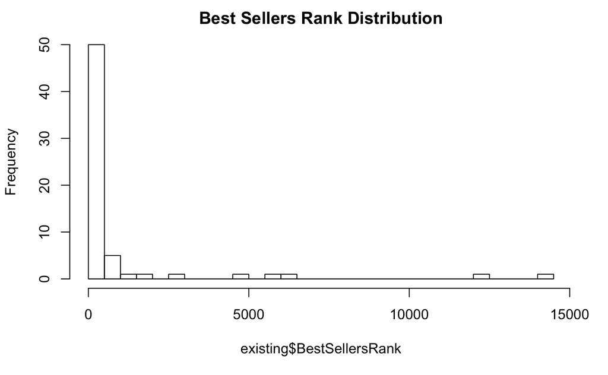

```r
hist(existing$BestSellersRank, main = "Best Sellers Rank Distribution", breaks =  49 )
```

```r
#pull BestSellers
bestSellersTable <- table(existing$BestSellersRank)
cbind(bestSellersTable)
```

```
      bestSellersTable
1                    3
2                    2
3                    2
4                    1
6                    2
7                    8
8                    1
9                    1
10                   1
11                   3
16                   1
17                   2
18                   1
22                   2
```

[output cut: 32 more lines]

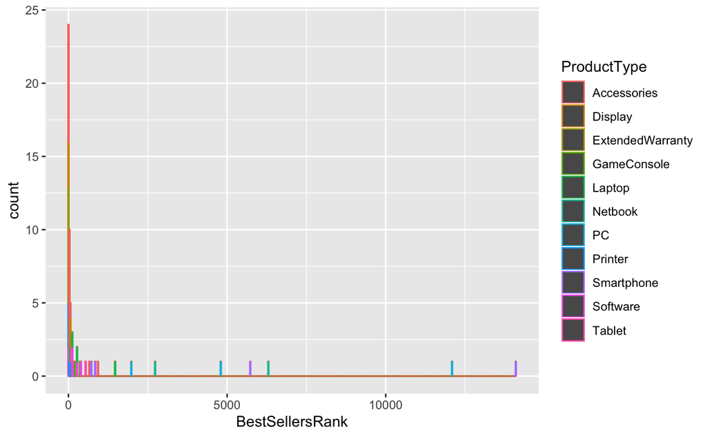

```r
ggplot(existing, aes(BestSellersRank, color = ProductType)) + geom_histogram(binwidth = 30)
```

```r
sort(existing$BestSellersRank )
```

```
 [1]     1     1     1     2     2     3     3     4     6     6     7     7     7     7
[15]     7     7     7     7     8     9    10    11    11    11    16    17    17    18
[29]    22    22    27    27    29    30    48    50    60    64    69    76   100   109
[43]   110   134   150   215   268   281   352   398   544   661   720   829   927  1473
[57]  1967  2723  4806  5742  6295 12076 14086
```

Outliers

```r
outlier_test_df <- outlier_test(existing$BestSellersRank,existing)
outlier_test_df
```

|  | ProductType | ProductNum | Price | x5StarReviews | x4StarReviews | x3StarReviews | x2StarReviews | x1StarReviews | PositiveServiceReview | NegativeServiceReview | Recommendproduct | BestSellersRank | ShippingWeight | ProductDepth | ProductWidth | ProductHeight | ProfitMargin | Volume |
| --- | --- | --- | --- | --- | --- | --- | --- | --- | --- | --- | --- | --- | --- | --- | --- | --- | --- | --- |
| 1 | PC | 101 | 949.00 | 3 | 3 | 2 | 0 | 0 | 2 | 0 | 0.9 | 1967 | 25.80 | 23.94 | 6.62 | 16.89 | 0.15 | 12 |
| 2 | PC | 102 | 2249.99 | 2 | 1 | 0 | 0 | 0 | 1 | 0 | 0.9 | 4806 | 50.00 | 35.00 | 31.75 | 19.00 | 0.25 | 8 |
| 3 | PC | 103 | 399.00 | 3 | 0 | 0 | 0 | 0 | 1 | 0 | 0.9 | 12076 | 17.40 | 10.50 | 8.30 | 10.20 | 0.08 | 12 |
| 16 | Accessories | 116 | 3.60 | 8 | 6 | 3 | 2 | 1 | 0 | 0 | 0.8 | 927 | 0.01 | 11.50 | 8.50 | 0.40 | 0.05 | 32 |
| 43 | Laptop | 143 | 770.60 | 22 | 14 | 4 | 5 | 6 | 6 | 2 | 0.7 | 1473 | 3.54 | 12.72 | 8.90 | 0.71 | 0.15 | 88 |
| 70 | Netbook | 177 | 379.99 | 1 | 0 | 1 | 1 | 0 | 0 | 1 | 0.3 | 6295 | 3.00 | 7.44 | 10.43 | 1.02 | 0.10 | 4 |
| 72 | Smartphone | 190 | 199.00 | 4 | 1 | 0 | 2 | 2 | 1 | 1 | 0.5 | 829 | 1.10 | 4.50 | 2.50 | 0.50 | 0.10 | 16 |
| 76 | Smartphone | 191 | 200.00 | 62 | 25 | 10 | 11 | 12 | 9 | 3 | 0.8 | 720 | 0.90 | 2.80 | 5.40 | 0.30 | 0.14 | 248 |
| 77 | Smartphone | 192 | 99.00 | 18 | 17 | 6 | 2 | 12 | 5 | 4 | 0.7 | 5742 | 0.70 | 2.80 | 5.30 | 0.40 | 0.17 | 72 |
| 78 | Netbook | 182 | 349.99 | 22 | 10 | 6 | 2 | 10 | 3 | 3 | 0.3 | 2723 | 5.00 | 7.57 | 10.47 | 1.43 | 0.12 | 88 |

[output cut: 1 more lines]

```r
my_outliers
```

```
 [1] 150 198 101 102 105 157 150 198 118 122 123 126 148 150 167 198 200 122 123 147 148 150
[23] 185 198 122 123 126 146 147 148 150 167 198 122 123 148 150 167 198 118 123 134 135 136
[45] 137 138 139 140 141 150 105 122 123 150 167 106 112 123 127 177 182
```

```r
my_outliers <- append_outliers(my_outliers,outlier_test_df)
my_outliers
```

```
 [1] 150 198 101 102 105 157 150 198 118 122 123 126 148 150 167 198 200 122 123 147 148 150
[23] 185 198 122 123 126 146 147 148 150 167 198 122 123 148 150 167 198 118 123 134 135 136
[45] 137 138 139 140 141 150 105 122 123 150 167 106 112 123 127 177 182 101 102 103 116 143
[67] 177 190 191 192 182 197
```

### 1.3.14 Shipping Weight

```r
unique_volume <- length(unique(existing$ShippingWeight))
unique_volume # 24 unique values
```

```
[1] 41
```

```r
summary(existing$ShippingWeight) # integer
```

```
   Min. 1st Qu.  Median    Mean 3rd Qu.    Max.
  0.010   0.375   2.000   8.718   9.000  63.000
```

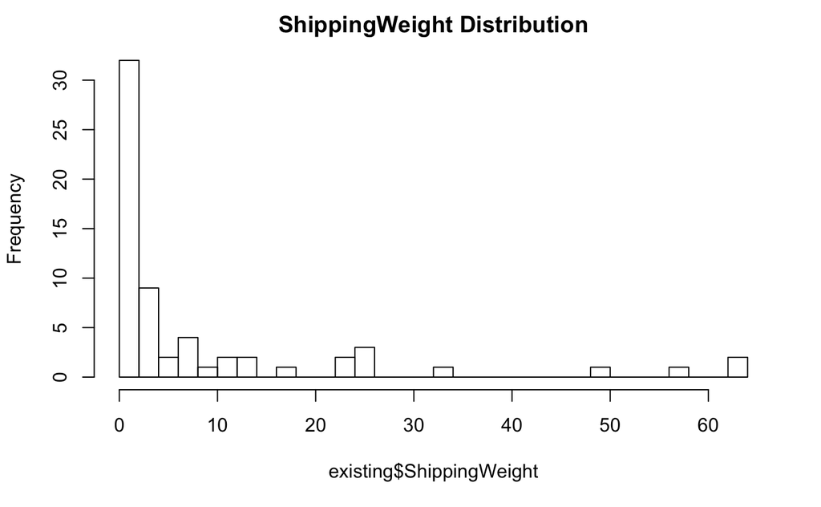

```r
hist(existing$ShippingWeight, main = "ShippingWeight Distribution", breaks =  unique_volume )
```

```r
table(existing$ShippingWeight)
```

```
 0.01  0.15   0.2  0.25  0.35   0.4  0.55   0.7  0.75   0.9     1   1.1   1.4   1.5   1.6
    2     1    11     1     1     2     2     1     1     2     2     1     1     2     1
    2   2.2   2.4     3  3.54   3.8     4     5   5.7     7  7.25     8    10 10.94    12
    1     3     1     2     1     1     1     1     1     2     1     1     1     1     1
   13  13.7  17.4  22.7    23    25  25.8  32.2    50    57    63
    1     1     1     1     1     2     1     1     1     1     2
```

Outliers

```r
outlier_test_df <- outlier_test(existing$ShippingWeight,existing)
outlier_test_df
```

|  | ProductType | ProductNum | Price | x5StarReviews | x4StarReviews | x3StarReviews | x2StarReviews | x1StarReviews | PositiveServiceReview | NegativeServiceReview | Recommendproduct | BestSellersRank | ShippingWeight | ProductDepth | ProductWidth | ProductHeight | ProfitMargin | Volume |
| --- | --- | --- | --- | --- | --- | --- | --- | --- | --- | --- | --- | --- | --- | --- | --- | --- | --- | --- |
| 1 | PC | 101 | 949.00 | 3 | 3 | 2 | 0 | 0 | 2 | 0 | 0.9 | 1967 | 25.8 | 23.94 | 6.62 | 16.89 | 0.15 | 12 |
| 2 | PC | 102 | 2249.99 | 2 | 1 | 0 | 0 | 0 | 1 | 0 | 0.9 | 4806 | 50.0 | 35.00 | 31.75 | 19.00 | 0.25 | 8 |
| 27 | Printer | 127 | 396.35 | 8 | 0 | 1 | 0 | 2 | 1 | 1 | 0.3 | 60 | 63.0 | 17.90 | 15.90 | 12.70 | 0.12 | 32 |
| 28 | Printer | 128 | 262.98 | 22 | 8 | 3 | 1 | 3 | 5 | 1 | 0.8 | 29 | 57.0 | 17.30 | 23.50 | 25.80 | 0.12 | 88 |
| 57 | Display | 157 | 1276.57 | 164 | 33 | 6 | 13 | 6 | 12 | 4 | 0.9 | 8 | 23.0 | 15.50 | 17.70 | 5.70 | 0.25 | 656 |
| 58 | Display | 158 | 783.98 | 26 | 13 | 7 | 5 | 16 | 4 | 5 | 0.6 | 50 | 25.0 | 29.20 | 9.90 | 23.00 | 0.16 | 104 |
| 60 | Printer | 160 | 129.99 | 74 | 25 | 7 | 6 | 9 | 4 | 2 | 0.9 | 6 | 32.2 | 15.70 | 15.90 | 12.40 | 0.10 | 296 |
| 61 | Printer | 161 | 128.49 | 58 | 33 | 10 | 3 | 6 | 5 | 2 | 0.9 | 11 | 22.7 | 15.70 | 15.90 | 10.60 | 0.12 | 232 |
| 62 | Printer | 162 | 141.95 | 4 | 0 | 0 | 0 | 3 | 0 | 1 | 0.5 | 76 | 25.0 | 19.50 | 18.00 | 14.00 | 0.14 | 16 |
| 68 | Printer | 168 | 395.00 | 8 | 0 | 1 | 0 | 2 | 3 | 0 | 0.8 | 69 | 63.0 | 17.90 | 15.90 | 12.70 | 0.09 | 32 |

```r
my_outliers
```

```
 [1] 150 198 101 102 105 157 150 198 118 122 123 126 148 150 167 198 200 122 123 147 148 150
[23] 185 198 122 123 126 146 147 148 150 167 198 122 123 148 150 167 198 118 123 134 135 136
[45] 137 138 139 140 141 150 105 122 123 150 167 106 112 123 127 177 182 101 102 103 116 143
[67] 177 190 191 192 182 197
```

```r
my_outliers <- append_outliers(my_outliers,outlier_test_df)
my_outliers
```

```
 [1] 150 198 101 102 105 157 150 198 118 122 123 126 148 150 167 198 200 122 123 147 148 150
[23] 185 198 122 123 126 146 147 148 150 167 198 122 123 148 150 167 198 118 123 134 135 136
[45] 137 138 139 140 141 150 105 122 123 150 167 106 112 123 127 177 182 101 102 103 116 143
[67] 177 190 191 192 182 197 101 102 127 128 157 158 160 161 162 168
```

```r
unique_volume <- length(unique(existing$ProductWidth))
unique_volume # 24 unique values
```

```
[1] 44
```

```r
summary(existing$ProductWidth) # integer
```

```
   Min. 1st Qu.  Median    Mean 3rd Qu.    Max.
  0.000   1.400   6.500   7.519  10.450  31.750
```

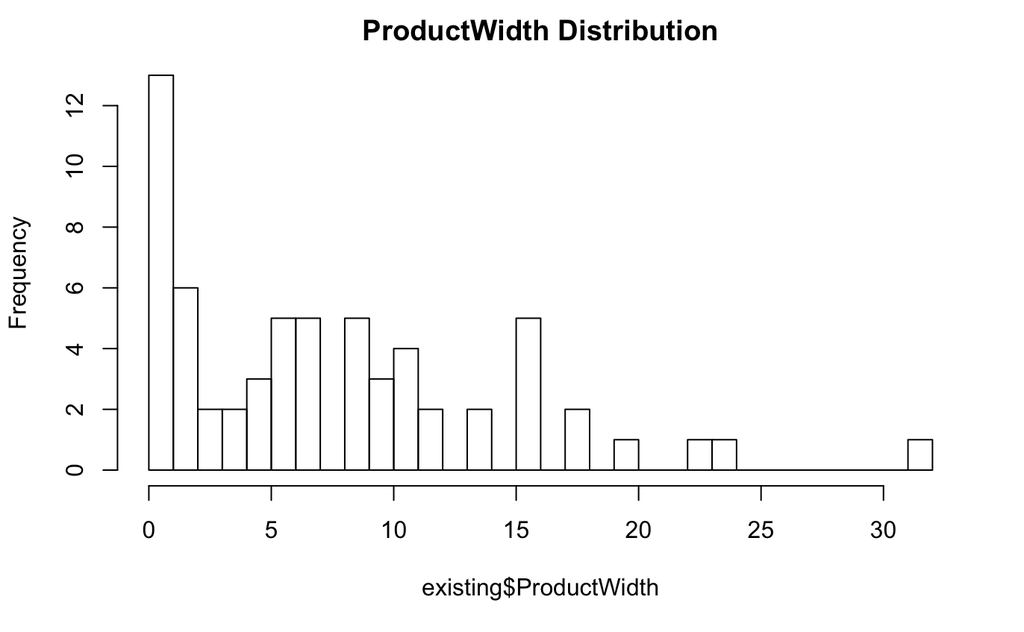

```r
hist(existing$ProductWidth, main = "ProductWidth Distribution", breaks =  unique_volume )
```

```r
table(existing$ProductWidth)
```

```
    0   0.3   0.5   1.3   1.4   1.8   2.5     3   3.5     4   4.2   4.5     5   5.3   5.4
   10     1     2     1     3     2     1     1     1     1     1     1     1     1     1
  5.5     6   6.5  6.62   6.7   6.9     7   8.2   8.3   8.5   8.9   9.8   9.9  10.2  10.4
    2     1     1     1     1     1     1     1     1     2     1     1     2     1     1
10.43 10.47  11.2  11.5  13.1  13.7  15.3  15.9  17.7    18    20  22.3  23.5 31.75
    1     1     1     1     1     1     1     4     1     1     1     1     1     1
```

Outliers

```r
outlier_test_df <- outlier_test(existing$ProductWidth,existing)
outlier_test_df
```

|  | ProductType | ProductNum | Price | x5StarReviews | x4StarReviews | x3StarReviews | x2StarReviews | x1StarReviews | PositiveServiceReview | NegativeServiceReview | Recommendproduct | BestSellersRank | ShippingWeight | ProductDepth | ProductWidth | ProductHeight | ProfitMargin | Volume |
| --- | --- | --- | --- | --- | --- | --- | --- | --- | --- | --- | --- | --- | --- | --- | --- | --- | --- | --- |
| 2 | PC | 102 | 2249.99 | 2 | 1 | 0 | 0 | 0 | 1 | 0 | 0.9 | 4806 | 50 | 35 | 31.75 | 19 | 0.25 | 8 |

```r
my_outliers
```

```
 [1] 150 198 101 102 105 157 150 198 118 122 123 126 148 150 167 198 200 122 123 147 148 150
[23] 185 198 122 123 126 146 147 148 150 167 198 122 123 148 150 167 198 118 123 134 135 136
[45] 137 138 139 140 141 150 105 122 123 150 167 106 112 123 127 177 182 101 102 103 116 143
[67] 177 190 191 192 182 197 101 102 127 128 157 158 160 161 162 168
```

```r
my_outliers <- append_outliers(my_outliers,outlier_test_df)
my_outliers
```

```
 [1] 150 198 101 102 105 157 150 198 118 122 123 126 148 150 167 198 200 122 123 147 148 150
[23] 185 198 122 123 126 146 147 148 150 167 198 122 123 148 150 167 198 118 123 134 135 136
[45] 137 138 139 140 141 150 105 122 123 150 167 106 112 123 127 177 182 101 102 103 116 143
[67] 177 190 191 192 182 197 101 102 127 128 157 158 160 161 162 168 102
```

### 1.3.16 Product Width

```r
unique_volume <- length(unique(existing$ProductWidth))
unique_volume # 24 unique values
```

```
[1] 44
```

```r
summary(existing$ProductWidth) # integer
```

```
   Min. 1st Qu.  Median    Mean 3rd Qu.    Max.
  0.000   1.400   6.500   7.519  10.450  31.750
```

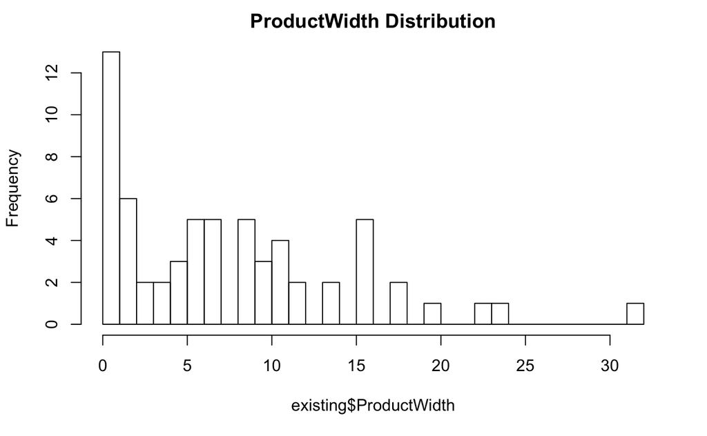

```r
hist(existing$ProductWidth, main = "ProductWidth Distribution", breaks =  unique_volume )
```

```r
table(existing$ProductWidth)
```

```
    0   0.3   0.5   1.3   1.4   1.8   2.5     3   3.5     4   4.2   4.5     5   5.3   5.4
   10     1     2     1     3     2     1     1     1     1     1     1     1     1     1
  5.5     6   6.5  6.62   6.7   6.9     7   8.2   8.3   8.5   8.9   9.8   9.9  10.2  10.4
    2     1     1     1     1     1     1     1     1     2     1     1     2     1     1
10.43 10.47  11.2  11.5  13.1  13.7  15.3  15.9  17.7    18    20  22.3  23.5 31.75
    1     1     1     1     1     1     1     4     1     1     1     1     1     1
```

Outliers

```r
outlier_test_df <- outlier_test(existing$ProductWidth,existing)
outlier_test_df
```

|  | ProductType | ProductNum | Price | x5StarReviews | x4StarReviews | x3StarReviews | x2StarReviews | x1StarReviews | PositiveServiceReview | NegativeServiceReview | Recommendproduct | BestSellersRank | ShippingWeight | ProductDepth | ProductWidth | ProductHeight | ProfitMargin | Volume |
| --- | --- | --- | --- | --- | --- | --- | --- | --- | --- | --- | --- | --- | --- | --- | --- | --- | --- | --- |
| 2 | PC | 102 | 2249.99 | 2 | 1 | 0 | 0 | 0 | 1 | 0 | 0.9 | 4806 | 50 | 35 | 31.75 | 19 | 0.25 | 8 |

```r
my_outliers
```

```
 [1] 150 198 101 102 105 157 150 198 118 122 123 126 148 150 167 198 200 122 123 147 148 150
[23] 185 198 122 123 126 146 147 148 150 167 198 122 123 148 150 167 198 118 123 134 135 136
[45] 137 138 139 140 141 150 105 122 123 150 167 106 112 123 127 177 182 101 102 103 116 143
[67] 177 190 191 192 182 197 101 102 127 128 157 158 160 161 162 168 102
```

```r
my_outliers <- append_outliers(my_outliers,outlier_test_df)
my_outliers
```

```
 [1] 150 198 101 102 105 157 150 198 118 122 123 126 148 150 167 198 200 122 123 147 148 150
[23] 185 198 122 123 126 146 147 148 150 167 198 122 123 148 150 167 198 118 123 134 135 136
[45] 137 138 139 140 141 150 105 122 123 150 167 106 112 123 127 177 182 101 102 103 116 143
[67] 177 190 191 192 182 197 101 102 127 128 157 158 160 161 162 168 102 102
```

### 1.3.17 Product Height

```r
unique_volume <- length(unique(existing$ProductHeight))
unique_volume # 24 unique values
```

```
[1] 42
```

```r
summary(existing$ProductHeight) # integer
```

```
   Min. 1st Qu.  Median    Mean 3rd Qu.    Max.
  0.000   0.400   1.500   5.459   8.250  25.800
```

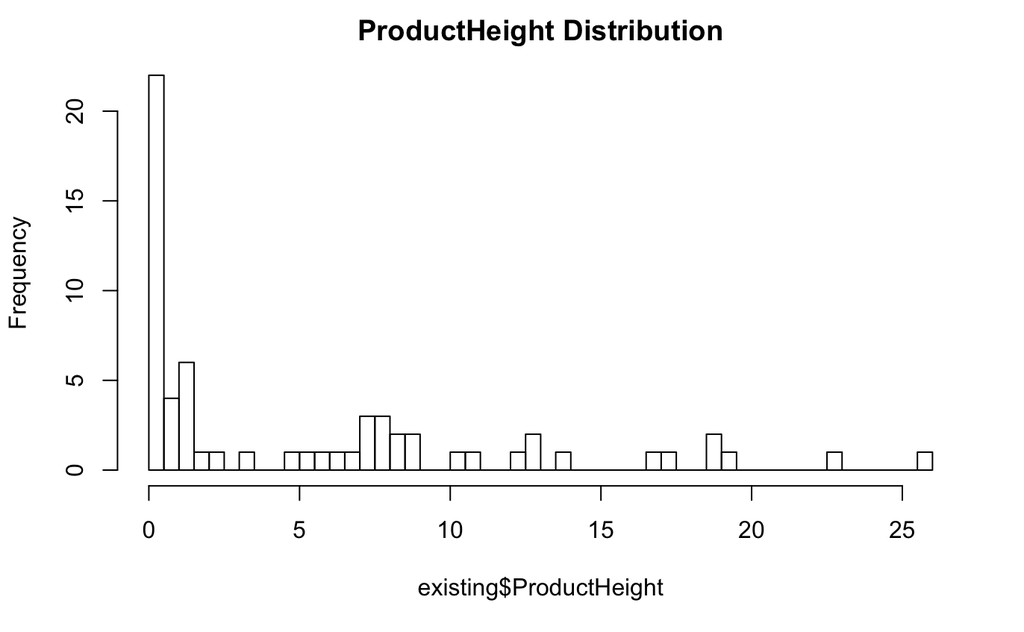

```r
hist(existing$ProductHeight, main = "ProductHeight Distribution", breaks =  unique_volume )
```

```r
table(existing$ProductHeight)
```

```
    0   0.3  0.38   0.4   0.5   0.6  0.71     1  1.02   1.2   1.3  1.43   1.5  1.75   2.2
   10     2     1     6     3     1     1     2     1     2     1     1     1     1     1
  3.2   4.8   5.2   5.7   6.4   6.7   7.2  7.25   7.5   7.6   7.8   8.2   8.3   8.8   8.9
    1     1     1     1     1     1     1     1     1     1     2     1     1     1     1
 10.2  10.6  12.4  12.7    14 16.89  17.5  18.9    19  19.1    23  25.8
    1     1     1     2     1     1     1     1     1     1     1     1
```

Outliers

```r
outlier_test_df <- outlier_test(existing$ProductHeight,existing)
outlier_test_df
```

|  | ProductType | ProductNum | Price | x5StarReviews | x4StarReviews | x3StarReviews | x2StarReviews | x1StarReviews | PositiveServiceReview | NegativeServiceReview | Recommendproduct | BestSellersRank | ShippingWeight | ProductDepth | ProductWidth | ProductHeight | ProfitMargin | Volume |
| --- | --- | --- | --- | --- | --- | --- | --- | --- | --- | --- | --- | --- | --- | --- | --- | --- | --- | --- |
| 28 | Printer | 128 | 262.98 | 22 | 8 | 3 | 1 | 3 | 5 | 1 | 0.8 | 29 | 57 | 17.3 | 23.5 | 25.8 | 0.12 | 88 |
| 58 | Display | 158 | 783.98 | 26 | 13 | 7 | 5 | 16 | 4 | 5 | 0.6 | 50 | 25 | 29.2 | 9.9 | 23.0 | 0.16 | 104 |

```r
my_outliers
```

```
 [1] 150 198 101 102 105 157 150 198 118 122 123 126 148 150 167 198 200 122 123 147 148 150
[23] 185 198 122 123 126 146 147 148 150 167 198 122 123 148 150 167 198 118 123 134 135 136
[45] 137 138 139 140 141 150 105 122 123 150 167 106 112 123 127 177 182 101 102 103 116 143
[67] 177 190 191 192 182 197 101 102 127 128 157 158 160 161 162 168 102 102
```

```r
my_outliers <- append_outliers(my_outliers,outlier_test_df)
my_outliers
```

```
 [1] 150 198 101 102 105 157 150 198 118 122 123 126 148 150 167 198 200 122 123 147 148 150
[23] 185 198 122 123 126 146 147 148 150 167 198 122 123 148 150 167 198 118 123 134 135 136
[45] 137 138 139 140 141 150 105 122 123 150 167 106 112 123 127 177 182 101 102 103 116 143
[67] 177 190 191 192 182 197 101 102 127 128 157 158 160 161 162 168 102 102 128 158
```

### 1.3.18 Profit Margin

```r
unique_volume <- length(unique(existing$ProfitMargin))
unique_volume # 24 unique values
```

```
[1] 15
```

```r
summary(existing$ProfitMargin) # integer
```

```
   Min. 1st Qu.  Median    Mean 3rd Qu.    Max.
  0.050   0.050   0.120   0.153   0.190   0.400
```

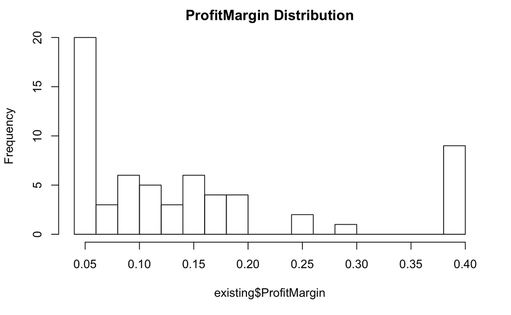

```r
hist(existing$ProfitMargin, main = "ProfitMargin Distribution", breaks =  unique_volume )
```

```r
table(existing$ProfitMargin)
```

```
0.05 0.08 0.09  0.1 0.12 0.13 0.14 0.15 0.16 0.17 0.18  0.2 0.25  0.3  0.4
  20    3    2    4    5    1    2    5    1    2    2    4    2    1    9
```

Outliers

```r
outlier_test_df <- outlier_test(existing$ProfitMargin,existing)
outlier_test_df
```

| ProductType | ProductNum | Price | x5StarReviews | x4StarReviews | x3StarReviews | x2StarReviews | x1StarReviews | PositiveServiceReview | NegativeServiceReview | Recommendproduct | BestSellersRank | ShippingWeight | ProductDepth | ProductWidth | ProductHeight | ProfitMargin | Volume |
| --- | --- | --- | --- | --- | --- | --- | --- | --- | --- | --- | --- | --- | --- | --- | --- | --- | --- |

```r
my_outliers
```

```
 [1] 150 198 101 102 105 157 150 198 118 122 123 126 148 150 167 198 200 122 123 147 148 150
[23] 185 198 122 123 126 146 147 148 150 167 198 122 123 148 150 167 198 118 123 134 135 136
[45] 137 138 139 140 141 150 105 122 123 150 167 106 112 123 127 177 182 101 102 103 116 143
[67] 177 190 191 192 182 197 101 102 127 128 157 158 160 161 162 168 102 102 128 158
```

```r
my_outliers <- append_outliers(my_outliers,outlier_test_df)
my_outliers
```

```
 [1] 150 198 101 102 105 157 150 198 118 122 123 126 148 150 167 198 200 122 123 147 148 150
[23] 185 198 122 123 126 146 147 148 150 167 198 122 123 148 150 167 198 118 123 134 135 136
[45] 137 138 139 140 141 150 105 122 123 150 167 106 112 123 127 177 182 101 102 103 116 143
[67] 177 190 191 192 182 197 101 102 127 128 157 158 160 161 162 168 102 102 128 158
```

### 1.3.19 Product Type

Product type is a categorical variable that was inputted as a factor but converted into a dummary variable, with multiple binary columns. The categories are:

```r
levels(existing$ProductType)
```

```
 [1] "Accessories"      "Display"          "ExtendedWarranty" "GameConsole"
 [5] "Laptop"           "Netbook"          "PC"               "Printer"
 [9] "PrinterSupplies"  "Smartphone"       "Software"         "Tablet"
```

Note that there are not actually any PrinterSupplies (since we removed all instances where sales volume is zero).

*Drop Levels*

```r
existing <- droplevels(existing)
#verify
levels(existing$ProductType)
```

```
 [1] "Accessories"      "Display"          "ExtendedWarranty" "GameConsole"
 [5] "Laptop"           "Netbook"          "PC"               "Printer"
 [9] "Smartphone"       "Software"         "Tablet"
```

*Dummify Product*

Now, let’s convert product type into dummy variables.

```r
# ~. stands for transform all characters and factors columns
dummy <- dummyVars(" ~ .", data = existing)
ready_data <- data.frame(predict(dummy, newdata = existing))
summary(ready_data)
```

```
 ProductType.Accessories ProductType.Display ProductType.ExtendedWarranty
 Min.   :0.0000          Min.   :0.00000     Min.   :0.0000
 1st Qu.:0.0000          1st Qu.:0.00000     1st Qu.:0.0000
 Median :0.0000          Median :0.00000     Median :0.0000
 Mean   :0.3175          Mean   :0.07937     Mean   :0.1429
 3rd Qu.:1.0000          3rd Qu.:0.00000     3rd Qu.:0.0000
 Max.   :1.0000          Max.   :1.00000     Max.   :1.0000
 ProductType.GameConsole ProductType.Laptop ProductType.Netbook ProductType.PC
 Min.   :0.00000         Min.   :0.00000    Min.   :0.00000     Min.   :0.00000
 1st Qu.:0.00000         1st Qu.:0.00000    1st Qu.:0.00000     1st Qu.:0.00000
 Median :0.00000         Median :0.00000    Median :0.00000     Median :0.00000
 Mean   :0.03175         Mean   :0.04762    Mean   :0.03175     Mean   :0.04762
 3rd Qu.:0.00000         3rd Qu.:0.00000    3rd Qu.:0.00000     3rd Qu.:0.00000
 Max.   :1.00000         Max.   :1.00000    Max.   :1.00000     Max.   :1.00000
 ProductType.Printer ProductType.Smartphone ProductType.Software ProductType.Tablet
 Min.   :0.0000      Min.   :0.00000        Min.   :0.00000      Min.   :0.00000
 1st Qu.:0.0000      1st Qu.:0.00000        1st Qu.:0.00000      1st Qu.:0.00000
 Median :0.0000      Median :0.00000        Median :0.00000      Median :0.00000
 Mean   :0.1111      Mean   :0.06349        Mean   :0.07937      Mean   :0.04762
 3rd Qu.:0.0000      3rd Qu.:0.00000        3rd Qu.:0.00000      3rd Qu.:0.00000
 Max.   :1.0000      Max.   :1.00000        Max.   :1.00000      Max.   :1.00000
   ProductNum        Price         x5StarReviews  x4StarReviews    x3StarReviews
 Min.   :101.0   Min.   :   3.60   Min.   :   1   Min.   :  0.00   Min.   :  0.00
 1st Qu.:123.5   1st Qu.:  58.49   1st Qu.:  19   1st Qu.:  7.00   1st Qu.:  3.00
 Median :144.0   Median : 141.95   Median :  77   Median : 27.00   Median :  8.00
 Mean   :144.7   Mean   : 273.21   Mean   : 214   Mean   : 47.29   Mean   : 17.59
 3rd Qu.:159.5   3rd Qu.: 369.99   3rd Qu.: 308   3rd Qu.: 37.50   3rd Qu.: 12.50
 Max.   :200.0   Max.   :2249.99   Max.   :2801   Max.   :431.00   Max.   :162.00
 x2StarReviews    x1StarReviews     PositiveServiceReview NegativeServiceReview
 Min.   :  0.00   Min.   :   0.00   Min.   :  0.00        Min.   :  0.000
 1st Qu.:  2.00   1st Qu.:   3.00   1st Qu.:  4.00        1st Qu.:  1.000
 Median :  3.00   Median :   9.00   Median :  7.00        Median :  3.000
 Mean   : 16.95   Mean   :  46.29   Mean   : 64.21        Mean   :  7.302
 3rd Qu.:  9.50   3rd Qu.:  18.00   3rd Qu.: 52.50        3rd Qu.:  8.000
 Max.   :370.00   Max.   :1654.00   Max.   :536.00        Max.   :112.000
 Recommendproduct BestSellersRank   ShippingWeight    ProductDepth     ProductWidth
 Min.   :0.2000   Min.   :    1.0   Min.   : 0.010   Min.   :  0.00   Min.   : 0.000
 1st Qu.:0.7000   1st Qu.:    7.0   1st Qu.: 0.375   1st Qu.:  5.00   1st Qu.: 1.400
 Median :0.8000   Median :   27.0   Median : 2.000   Median :  7.90   Median : 6.500
 Mean   :0.7619   Mean   :  884.2   Mean   : 8.718   Mean   : 15.48   Mean   : 7.519
 3rd Qu.:0.9000   3rd Qu.:  274.5   3rd Qu.: 9.000   3rd Qu.: 14.40   3rd Qu.:10.450
 Max.   :0.9000   Max.   :14086.0   Max.   :63.000   Max.   :300.00   Max.   :31.750
 ProductHeight     ProfitMargin       Volume
 Min.   : 0.000   Min.   :0.050   Min.   :    4.0
 1st Qu.: 0.400   1st Qu.:0.050   1st Qu.:   76.0
 Median : 1.500   Median :0.120   Median :  308.0
 Mean   : 5.459   Mean   :0.153   Mean   :  856.1
 3rd Qu.: 8.250   3rd Qu.:0.190   3rd Qu.: 1232.0
 Max.   :25.800   Max.   :0.400   Max.   :11204.0
```

## 1.4 Review of outliers

```r
my_outliers
```

```
 [1] 150 198 101 102 105 157 150 198 118 122 123 126 148 150 167 198 200 122 123 147 148 150
[23] 185 198 122 123 126 146 147 148 150 167 198 122 123 148 150 167 198 118 123 134 135 136
[45] 137 138 139 140 141 150 105 122 123 150 167 106 112 123 127 177 182 101 102 103 116 143
[67] 177 190 191 192 182 197 101 102 127 128 157 158 160 161 162 168 102 102 128 158
```

```r
sort(my_outliers)
```

```
 [1] 101 101 101 102 102 102 102 102 103 105 105 106 112 116 118 118 122 122 122 122 122 123
[23] 123 123 123 123 123 123 126 126 127 127 128 128 134 135 136 137 138 139 140 141 143 146
[45] 147 147 148 148 148 148 150 150 150 150 150 150 150 150 157 157 158 158 160 161 162 167
[67] 167 167 167 168 177 177 182 182 185 190 191 192 197 198 198 198 198 198 198 200
```

```r
table(my_outliers)
```

```
my_outliers
101 102 103 105 106 112 116 118 122 123 126 127 128 134 135 136 137 138 139 140 141 143 146
  3   5   1   2   1   1   1   2   5   7   2   2   2   1   1   1   1   1   1   1   1   1   1
147 148 150 157 158 160 161 162 167 168 177 182 185 190 191 192 197 198 200
  2   4   8   2   2   1   1   1   4   1   2   2   1   1   1   1   1   6   1
```

Since this is a small dataset, we will only look at products that are considered outliers four or more times. I need to figure out how to do this with code instead of manually, but here it is typed, for now:

```r
my_outiers_refined <- c(102,122,123,148,150,167,198)
```

We will create two datasets.

ready_data_outliers_rm is with the outliers removed ready_data is as it.

```r
ready_data_outliers_rm <- ready_data[!ready_data$ProductNum %in% my_outiers_refined,]
#
```

## 1.5 Normalize Data

```r
#ready_data_normalized<- preProcess(ready_data, method='range')
#str(ready_data_normalized)
```

I need to normalize my data but I don’t have an easy way to do this. It’s taking forever to find a way to do this so I’m ust going to move on for now.

## 1.6 Split Data

We have two datasets right now specifically for resting: ready_data and ready_data_outliers_rm. Let’s prepare both with a training, testing split.

### 1.6.1 Split Data with Outliers

```r
# create reproducable results from random sampling
set.seed(234)
# create 75% sample of row indices
in_training <- createDataPartition(ready_data$Volume, p = .75, list = FALSE)
# create 75% sample of data and save it to train_data
train_data <- ready_data[in_training, ]
# create 25% sample of data and save it to test_data
test_data <- ready_data[-in_training, ]
# verify split percentages
nrow(train_data) / nrow(ready_data)
```

```
[1] 0.7619048
```

### 1.6.2 Split Data without Outliers

```r
# create reproducable results from random sampling
set.seed(234)
# create 75% sample of row indices
in_training_outliers_rm <- createDataPartition(ready_data_outliers_rm$Volume, p = .75, list = FALSE)
# create 75% sample of data and save it to train_data
train_data_outliers_rm <- ready_data_outliers_rm[in_training_outliers_rm, ]
# create 25% sample of data and save it to test_data
test_data_outliers_rm <- ready_data_outliers_rm[-in_training_outliers_rm, ]
# verify split percentages
nrow(train_data_outliers_rm) / nrow(ready_data_outliers_rm)
```

```
[1] 0.7857143
```

# 2 Train Model

## 2.1 Linear Model

What are the assumptions of linear regression?

In order for linear regression to work, our data must meet the following assumptions:

- Must have some linear relationship
- The variabes must have multivariate normality (normally distributed)
- No auto-correlation
- Homoscedasticity: residuals are equally distributed across regression lines

  To predict volume, we will use regression.

Why regression analysis?

Regression is useful because you can use multiple predictor variables (multiple regression), continous and categorical (factors) varaibles, higher-order terms (what’s this), and interaction terms. The best part of regression is that it allows us to look at multiple predictors. In the real world, so many variables are intertwined, and correlated with each other. The following excerpt summarizes this concept well:

"Suppose you’re a researcher and you are studying a question that involves intertwined predictors. For example, you want to determine:

- whether socio-economic status or race has a larger effect on educational achievement
- the importance of education versus IQ on earnings
- how exercise habits and diet effect weight
- how drinking coffee and smoking cigarettes are related to heart disease
- if a specific exercise intervention (separate from overall activity levels) increases bone density These are all research questions where the predictors are likely to be correlated with each other and they could all influence the response variable. How do you untangle this web and separate out the effects? How do you determine which variables are significant and how large of a role does each one play? Regression comes to the rescue!"

In our case, we have many product attributes that are our predictor variables.

Since we’re running a regression problem, we should normalize our data. This is not necessary for our categorical variables.

The numerical variables that we need to normalize are Price, Reviews, Service Reviews, BestSellersRank,ShippingWeight, ProductDepth,ProductWidth, ProductHeight, ProfitMargin, and Volume.

Do we normalize the response/target variable as well?

### 2.1.1 Model 1: Training Data, Regular

Create a linear model that uses volume as its dependent variable. Use summary() function of R to evaluate model, with R^2.

While we want to keep ProductNum in the dataset because it is useful for reference of specific rows, it has no logical relationship with volume. It is merely an identifier so we will keep special attention to not include it as a predictor variable.

```r
lm_model_1<-lm(Volume ~ . - ProductNum, train_data)
summary(lm_model_1)
```

```
essentially perfect fit: summary may be unreliable
```

```
Call:
lm(formula = Volume ~ . - ProductNum, data = train_data)

Residuals:
       Min         1Q     Median         3Q        Max
-2.885e-12 -3.896e-13  6.910e-14  5.089e-13  3.861e-12

Coefficients: (1 not defined because of singularities)
                               Estimate Std. Error    t value Pr(>|t|)
(Intercept)                  -2.458e-12  2.460e-12 -9.990e-01   0.3286
ProductType.Accessories       8.783e-13  1.653e-12  5.310e-01   0.6004
ProductType.Display          -1.386e-12  1.732e-12 -8.000e-01   0.4320
ProductType.ExtendedWarranty -3.033e-12  4.082e-12 -7.430e-01   0.4653
ProductType.GameConsole      -6.343e-12  2.305e-12 -2.752e+00   0.0116 *
ProductType.Laptop            6.641e-13  1.816e-12  3.660e-01   0.7181
ProductType.Netbook           3.349e-13  2.289e-12  1.460e-01   0.8850
ProductType.PC               -5.079e-13  2.225e-12 -2.280e-01   0.8215
ProductType.Printer          -1.658e-12  2.437e-12 -6.800e-01   0.5034
ProductType.Smartphone       -6.488e-13  1.877e-12 -3.460e-01   0.7329
ProductType.Software         -1.994e-12  1.945e-12 -1.025e+00   0.3164
ProductType.Tablet                   NA         NA         NA       NA
Price                        -9.959e-16  1.631e-15 -6.110e-01   0.5476
x5StarReviews                 4.000e+00  2.323e-15  1.722e+15   <2e-16 ***
x4StarReviews                 3.045e-14  3.142e-14  9.690e-01   0.3430
x3StarReviews                -4.179e-14  6.396e-14 -6.530e-01   0.5203
x2StarReviews                -1.227e-13  9.441e-14 -1.300e+00   0.2072
x1StarReviews                 6.191e-14  3.474e-14  1.782e+00   0.0885 .
PositiveServiceReview        -1.525e-14  5.659e-15 -2.695e+00   0.0132 *
NegativeServiceReview        -1.306e-14  6.469e-14 -2.020e-01   0.8419
Recommendproduct             -4.780e-13  2.375e-12 -2.010e-01   0.8423
BestSellersRank               7.911e-17  1.542e-16  5.130e-01   0.6130
ShippingWeight                3.429e-14  5.666e-14  6.050e-01   0.5513
ProductDepth                 -8.676e-15  2.041e-14 -4.250e-01   0.6748
ProductWidth                  6.460e-15  8.835e-14  7.300e-02   0.9424
ProductHeight                 1.976e-14  6.540e-14  3.020e-01   0.7654
ProfitMargin                  1.940e-11  1.267e-11  1.532e+00   0.1399
---
Signif. codes:  0 ‘***’ 0.001 ‘**’ 0.01 ‘*’ 0.05 ‘.’ 0.1 ‘ ’ 1

Residual standard error: 1.682e-12 on 22 degrees of freedom
Multiple R-squared:      1, Adjusted R-squared:      1
F-statistic: 2.324e+30 on 25 and 22 DF,  p-value: < 2.2e-16
```

Per the results, this model was “essentially [a] perfect fit” and therefore “unreliable”. This happens when there is no variance, as shown by R-Squared equal to 1.

Why is our model unreliable?

R-Squared is calculated as 1-(Explained Varation/ TotalVariation). Total Varation is the sum of all instances of y from the mean of y, squared. This will always be a positive number. Explained variation is the sum of the difference of all instances of y and the predicted value for that instance of y, squared. We get 1 for R-Squared when the difference between all the instances of y and the predicted values of y are the same. There’s no difference, which means that there is no variance.

To find out why, we will look at the correlation matrix. There must be variable that has perfect correlation.

### 2.1.2 Model 1: Training Data, Regular: Correlation

While correlation doesn’t always imply causation,we want to see the correlation between the relevant independent variables and the dependent variable. We will use the cor() function to calculate the correlation and the corpolot() function to visuallly ascertain the correlation between all of the features.

Correlation values fall within -1 and 1 with variables have string positive relationships having correlation values closer to 1 and strong negative relationships with values closer to -1.

For feature selection, we want to remove features that are highly correlated with each other. These are linearly dependent and hence have almost the same effect on the dependent variable. Therefore, we can remove one of the features in our model. More features than necessary can result in overfitting for our unique case of attributes and can slow down the model.

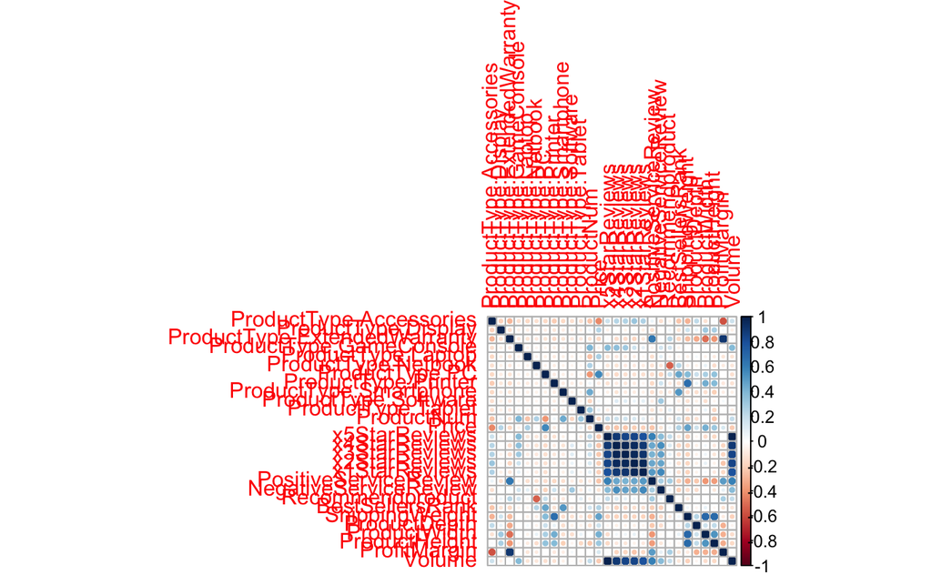

```r
corrData <- cor(train_data)
corrplot(corrData)
```

```r
any_over_90 <- function(corrMatrix) any(corrMatrix > .9 , na.rm = TRUE)
any_under_90 <- function(corrMatrix) any(corrMatrix < -.9, na.rm = TRUE)
corrData %>%
  focus_if(any_over_90, mirror = TRUE)
```

| rowname | ProductType.ExtendedWarranty | x5StarReviews | x4StarReviews | x3StarReviews | x2StarReviews | x1StarReviews | ProfitMargin | Volume |
| --- | --- | --- | --- | --- | --- | --- | --- | --- |
| ProductType.ExtendedWarranty | NA | 0.02736747 | -0.1481707 | -0.1474556 | -0.1771556 | -0.1018127 | 0.90013738 | 0.02736747 |
| x5StarReviews | 0.02736747 | NA | 0.8940452 | 0.8445387 | 0.8401748 | 0.7955364 | -0.01478199 | 1.00000000 |
| x4StarReviews | -0.14817074 | 0.89404516 | NA | 0.9733230 | 0.9504442 | 0.8973606 | -0.17067888 | 0.89404516 |
| x3StarReviews | -0.14745563 | 0.84453872 | 0.9733230 | NA | 0.9664888 | 0.9125385 | -0.17786202 | 0.84453872 |
| x2StarReviews | -0.17715558 | 0.84017478 | 0.9504442 | 0.9664888 | NA | 0.9638058 | -0.23018444 | 0.84017478 |
| x1StarReviews | -0.10181274 | 0.79553644 | 0.8973606 | 0.9125385 | 0.9638058 | NA | -0.16212484 | 0.79553644 |
| ProfitMargin | 0.90013738 | -0.01478199 | -0.1706789 | -0.1778620 | -0.2301844 | -0.1621248 | NA | -0.01478199 |
| Volume | 0.02736747 | 1.00000000 | 0.8940452 | 0.8445387 | 0.8401748 | 0.7955364 | -0.01478199 | NA |

```r
corrData %>%
  focus_if(any_under_90, mirror = TRUE)
```

```
Error in focus_if.cor_df(x, .predicate, ..., mirror = mirror) :
  No variables were TRUE given the function.
```

No variables have strong negative correlations.

Volume and x5StarReviews have perfect correlation, which must be the reason why R-Squared is 1, and why our regression line has a perfect fit. We will drop this 5-Star reviews.

Furthermore, there is multicollinearity with 1-2 star reviews, and 3-4 star reviews, which both have correlations above .9.

We can drop the variables that are multocollinear. We can combine them and bin them. Since we already have a large number of predictors, we will use the simple method and drop 2star and 4 star reviews, since they’re both highly correlated with 1 and 3star reviews, respectively.

In the future, we could look at the VIF score for multocollinearity. We could also look at distributions a bit more to see which particular reviews to drop. I simply picked 2 and 4.

Let’s look at the variance inflation factor VIF = 1/ (1- R-Sqauared for a certain predictor)

1= not correlated Between 1 and 5 = moderalty correlated Greater than 5 > highly correlated

```r
vif(lm_model_1)
```

```
Error in vif.default(lm_model_1) :
  there are aliased coefficients in the model
```

Let’s try this again after removing the variable with perfect correlation.

```r
# remove 5-star reviews, 2-star reviews, and 4-star reviews.
train_data_after_perfect_correlation <- select(train_data, -c(x5StarReviews ) )
#verify
str(train_data_after_perfect_correlation)
```

```
'data.frame':   48 obs. of  27 variables:
 $ ProductType.Accessories     : num  0 0 0 0 0 1 1 1 1 1 ...
 $ ProductType.Display         : num  0 0 0 0 0 0 0 0 0 0 ...
 $ ProductType.ExtendedWarranty: num  0 0 0 0 0 0 0 0 0 0 ...
 $ ProductType.GameConsole     : num  0 0 0 0 0 0 0 0 0 0 ...
 $ ProductType.Laptop          : num  0 0 0 1 1 0 0 0 0 0 ...
 $ ProductType.Netbook         : num  0 0 0 0 0 0 0 0 0 0 ...
 $ ProductType.PC              : num  1 1 1 0 0 0 0 0 0 0 ...
 $ ProductType.Printer         : num  0 0 0 0 0 0 0 0 0 0 ...
 $ ProductType.Smartphone      : num  0 0 0 0 0 0 0 0 0 0 ...
 $ ProductType.Software        : num  0 0 0 0 0 0 0 0 0 0 ...
 $ ProductType.Tablet          : num  0 0 0 0 0 0 0 0 0 0 ...
 $ ProductNum                  : num  101 102 103 104 105 108 110 112 114 117 ...
 $ Price                       : num  949 2250 399 410 1080 ...
 $ x4StarReviews               : num  3 1 0 19 31 19 1 25 62 5 ...
 $ x3StarReviews               : num  2 0 0 8 11 12 1 6 13 2 ...
 $ x2StarReviews               : num  0 0 0 3 7 5 0 3 8 2 ...
 $ x1StarReviews               : num  0 0 0 9 36 9 0 3 16 1 ...
 $ PositiveServiceReview       : num  2 1 1 7 7 5 2 9 44 0 ...
 $ NegativeServiceReview       : num  0 0 0 8 20 3 0 2 3 0 ...
 $ Recommendproduct            : num  0.9 0.9 0.9 0.8 0.7 0.7 0.9 0.2 0.9 0.8 ...
 $ BestSellersRank             : num  1967 4806 12076 109 268 ...
 $ ShippingWeight              : num  25.8 50 17.4 5.7 7 12 0.75 2.2 0.35 0.01 ...
 $ ProductDepth                : num  23.9 35 10.5 15 12.9 ...
 $ ProductWidth                : num  6.62 31.75 8.3 9.9 0.3 ...
 $ ProductHeight               : num  16.9 19 10.2 1.3 8.9 ...
 $ ProfitMargin                : num  0.15 0.25 0.08 0.08 0.09 0.05 0.05 0.05 0.05 0.05 ...
 $ Volume                      : num  12 8 12 196 232 ...
```

```r
lm_model_perfect_correlation<-lm(Volume ~ . - ProductNum, train_data_after_perfect_correlation)

#vif(lm_model_perfect_correlation)# the aliased coefficient error is still occuring

# let's try a different method
alias( lm( Volume ~ . - ProductNum, train_data_after_perfect_correlation ) )
```

```
Model :
Volume ~ (ProductType.Accessories + ProductType.Display + ProductType.ExtendedWarranty +
    ProductType.GameConsole + ProductType.Laptop + ProductType.Netbook +
    ProductType.PC + ProductType.Printer + ProductType.Smartphone +
    ProductType.Software + ProductType.Tablet + ProductNum +
    Price + x4StarReviews + x3StarReviews + x2StarReviews + x1StarReviews +
    PositiveServiceReview + NegativeServiceReview + Recommendproduct +
    BestSellersRank + ShippingWeight + ProductDepth + ProductWidth +
    ProductHeight + ProfitMargin) - ProductNum

Complete :
                   (Intercept) ProductType.Accessories ProductType.Display
ProductType.Tablet  1          -1                      -1
                   ProductType.ExtendedWarranty ProductType.GameConsole ProductType.Laptop
ProductType.Tablet -1                           -1                      -1
                   ProductType.Netbook ProductType.PC ProductType.Printer
ProductType.Tablet -1                  -1             -1
                   ProductType.Smartphone ProductType.Software Price x4StarReviews
ProductType.Tablet -1                     -1                    0     0
                   x3StarReviews x2StarReviews x1StarReviews PositiveServiceReview
ProductType.Tablet  0             0             0             0
                   NegativeServiceReview Recommendproduct BestSellersRank ShippingWeight
ProductType.Tablet  0                     0                0               0
                   ProductDepth ProductWidth ProductHeight ProfitMargin
ProductType.Tablet  0            0            0             0
```

In this context, ‘’alias’’ refers to the variables that are linearly dependent on others (i.e. cause perfect multicollinearity).

https://stats.stackexchange.com/questions/112442/what-are-aliased-coefficients

https://stats.stackexchange.com/questions/31270/what-is-the-difference-between-linearly-dependent-and-linearly-correlated/76618#76618

We can see that Tablets are linearly dependent with a lot of other product types. I will remove that.

```r
# remove 5-star reviews, 2-star reviews, and 4-star reviews.
train_data_after_perfect_correlation_alias <- select(train_data_after_perfect_correlation, -c(ProductType.Tablet) )
#verify


lm_model_after_perfect_correlation_alias<-lm(Volume ~ . - ProductNum, train_data_after_perfect_correlation_alias)

summary(lm_model_after_perfect_correlation_alias)
```

```
Call:
lm(formula = Volume ~ . - ProductNum, data = train_data_after_perfect_correlation_alias)

Residuals:
     Min       1Q   Median       3Q      Max
-1344.56  -305.51    70.64   192.12   942.05

Coefficients:
                               Estimate Std. Error t value Pr(>|t|)
(Intercept)                  -930.51944  861.36700  -1.080 0.291215
ProductType.Accessories        77.41066  593.03802   0.131 0.897280
ProductType.Display          -103.83031  621.36615  -0.167 0.868752
ProductType.ExtendedWarranty -194.16608 1464.63541  -0.133 0.895687
ProductType.GameConsole       692.58611  814.73937   0.850 0.404048
ProductType.Laptop            -15.85718  651.91783  -0.024 0.980804
ProductType.Netbook           829.63761  803.40142   1.033 0.312502
ProductType.PC               -642.36548  787.26754  -0.816 0.422903
ProductType.Printer           440.75700  869.84933   0.507 0.617185
ProductType.Smartphone        -47.64887  673.64905  -0.071 0.944222
ProductType.Software         -710.48814  682.26367  -1.041 0.308528
Price                           0.45679    0.57755   0.791 0.437078
x4StarReviews                  36.84453    8.25577   4.463 0.000178 ***
x3StarReviews                 -57.27208   19.61060  -2.920 0.007696 **
x2StarReviews                  20.28425   33.62573   0.603 0.552255
x1StarReviews                   7.97613   12.35786   0.645 0.525036
PositiveServiceReview          -0.59428    2.02754  -0.293 0.772071
NegativeServiceReview         -50.83536   20.65969  -2.461 0.021803 *
Recommendproduct             1099.88943  821.12322   1.339 0.193497
BestSellersRank                 0.05932    0.05396   1.099 0.282936
ShippingWeight                 22.18602   19.80661   1.120 0.274218
ProductDepth                    6.54108    7.19726   0.909 0.372866
ProductWidth                  -94.74456   24.80957  -3.819 0.000881 ***
ProductHeight                  -8.54653   23.40850  -0.365 0.718370
ProfitMargin                 2671.86921 4512.25075   0.592 0.559536
---
Signif. codes:  0 ‘***’ 0.001 ‘**’ 0.01 ‘*’ 0.05 ‘.’ 0.1 ‘ ’ 1

Residual standard error: 603.8 on 23 degrees of freedom
Multiple R-squared:  0.949, Adjusted R-squared:  0.8958
F-statistic: 17.83 on 24 and 23 DF,  p-value: 7.944e-10
```

```r
#vif(lm_model_perfect_correlation)# the aliased coefficient error is still occuring
```

Now, let’s check for Variable Importance factors

```r
#verify
vif(lm_model_after_perfect_correlation_alias)
```

```
     ProductType.Accessories          ProductType.Display ProductType.ExtendedWarranty
                    9.567218                     3.883484                    39.230396
     ProductType.GameConsole           ProductType.Laptop          ProductType.Netbook
                    3.490108                     3.278938                     3.393647
              ProductType.PC          ProductType.Printer       ProductType.Smartphone
                    4.781808                     9.296943                     3.501183
        ProductType.Software                        Price                x4StarReviews
                    2.447406                     7.130514                    60.801420
               x3StarReviews                x2StarReviews                x1StarReviews
                   52.376693                   110.493560                    42.435905
       PositiveServiceReview        NegativeServiceReview             Recommendproduct
                    8.077253                     4.952100                     2.897665
             BestSellersRank               ShippingWeight                 ProductDepth
                    3.170791                    11.167795                     1.733112
                ProductWidth                ProductHeight                 ProfitMargin
                    4.123634                     3.528385                    38.982022
```

A rule of thumb commonly used in practice is if a VIF is > 10, you have high multicollinearity.

https://blog.minitab.com/blog/starting-out-with-statistical-software/what-in-the-world-is-a-vif

Which variables have VIF greater than 10?

x4StarReviews x3StarReviews x2StarReviews x1StarReviews ShippingWeight ProductType.ExtendedWarranty ProfitMargin

We were already going to remove 2 and 4 star reviews because of their scores in the correlation matrix. Let’s remove them and then rerun theVIF.

```r
# remove 5-star reviews, 2-star reviews, and 4-star reviews.
train_data_after_perfect_correlation_alias_VIF1 <- select(train_data_after_perfect_correlation_alias, -c(x2StarReviews,x4StarReviews) )

lm_model_after_perfect_correlation_alias_VIF1<-lm(Volume ~ . - ProductNum, train_data_after_perfect_correlation_alias_VIF1)
vif(lm_model_after_perfect_correlation_alias_VIF1)
```

```
     ProductType.Accessories          ProductType.Display ProductType.ExtendedWarranty
                    9.195698                     3.724713                    36.039844
     ProductType.GameConsole           ProductType.Laptop          ProductType.Netbook
                    2.902793                     3.263378                     3.379161
              ProductType.PC          ProductType.Printer       ProductType.Smartphone
                    4.748530                     8.987392                     3.488414
        ProductType.Software                        Price                x3StarReviews
                    2.395757                     6.592420                    11.666787
               x1StarReviews        PositiveServiceReview        NegativeServiceReview
                   13.968761                     5.265875                     2.992914
            Recommendproduct              BestSellersRank               ShippingWeight
                    2.830578                     3.164951                    10.647429
                ProductDepth                 ProductWidth                ProductHeight
                    1.430323                     4.122512                     3.409481
                ProfitMargin
                   38.557328
```

```r
#verify
```

The VIF scores have decreased a bit, but some are still pretty high. Let’s just remove all of the ones with high VIFs.

```r
# remove 5-star reviews, 2-star reviews, and 4-star reviews.
train_data_after_perfect_correlation_alias_VIF2 <- select(train_data_after_perfect_correlation_alias_VIF1, -c(x1StarReviews,ProfitMargin,ProductType.ExtendedWarranty,x3StarReviews,ShippingWeight) )

lm_model_after_perfect_correlation_alias_VIF2<-lm(Volume ~ . - ProductNum, train_data_after_perfect_correlation_alias_VIF2)
vif(lm_model_after_perfect_correlation_alias_VIF2)
```

```
ProductType.Accessories     ProductType.Display ProductType.GameConsole
               3.313818                2.551840                1.484848
     ProductType.Laptop     ProductType.Netbook          ProductType.PC
               1.856510                2.608170                3.777659
    ProductType.Printer  ProductType.Smartphone    ProductType.Software
               3.881432                2.493244                1.618446
                  Price   PositiveServiceReview   NegativeServiceReview
               3.159082                2.047943                1.604179
       Recommendproduct         BestSellersRank            ProductDepth
               2.021218                2.835758                1.353103
           ProductWidth           ProductHeight
               2.763186                2.373240
```

```r
summary(lm_model_after_perfect_correlation_alias_VIF2)
```

```
Call:
lm(formula = Volume ~ . - ProductNum, data = train_data_after_perfect_correlation_alias_VIF2)

Residuals:
    Min      1Q  Median      3Q     Max
-3407.6  -376.5   -16.5   240.3  4161.7

Coefficients:
                          Estimate Std. Error t value Pr(>|t|)
(Intercept)             -1.390e+03  1.363e+03  -1.019   0.3162
ProductType.Accessories  1.733e+03  7.814e+02   2.218   0.0343 *
ProductType.Display      1.503e+03  1.128e+03   1.333   0.1926
ProductType.GameConsole  4.863e+03  1.190e+03   4.087   0.0003 ***
ProductType.Laptop       1.170e+03  1.098e+03   1.065   0.2954
ProductType.Netbook      9.596e+02  1.577e+03   0.609   0.5474
ProductType.PC           8.396e+02  1.567e+03   0.536   0.5960
ProductType.Printer      1.069e+03  1.258e+03   0.849   0.4024
ProductType.Smartphone   1.325e+03  1.273e+03   1.041   0.3062
ProductType.Software     1.368e+03  1.242e+03   1.101   0.2795
Price                   -4.789e-02  8.607e-01  -0.056   0.9560
PositiveServiceReview    1.143e+01  2.286e+00   5.001 2.32e-05 ***
NegativeServiceReview    2.772e+01  2.633e+01   1.053   0.3008
Recommendproduct        -1.641e+02  1.535e+03  -0.107   0.9156
BestSellersRank          6.709e-02  1.142e-01   0.587   0.5614
ProductDepth             5.379e+00  1.424e+01   0.378   0.7082
ProductWidth             1.206e+01  4.547e+01   0.265   0.7926
ProductHeight            1.108e+00  4.298e+01   0.026   0.9796
---
Signif. codes:  0 ‘***’ 0.001 ‘**’ 0.01 ‘*’ 0.05 ‘.’ 0.1 ‘ ’ 1

Residual standard error: 1352 on 30 degrees of freedom
Multiple R-squared:  0.6665,    Adjusted R-squared:  0.4775
F-statistic: 3.527 on 17 and 30 DF,  p-value: 0.001259
```

```r
#verify
```

Now that the VIF scores are decent, let’s run the model now to see what R-Squared is after accounting for multicollinearity and perfect corerlation.

```r
summary(lm_model_after_perfect_correlation_alias_VIF2)
```

```
Call:
lm(formula = Volume ~ . - ProductNum, data = train_data_after_perfect_correlation_alias_VIF2)

Residuals:
    Min      1Q  Median      3Q     Max
-3407.6  -376.5   -16.5   240.3  4161.7

Coefficients:
                          Estimate Std. Error t value Pr(>|t|)
(Intercept)             -1.390e+03  1.363e+03  -1.019   0.3162
ProductType.Accessories  1.733e+03  7.814e+02   2.218   0.0343 *
ProductType.Display      1.503e+03  1.128e+03   1.333   0.1926
ProductType.GameConsole  4.863e+03  1.190e+03   4.087   0.0003 ***
ProductType.Laptop       1.170e+03  1.098e+03   1.065   0.2954
ProductType.Netbook      9.596e+02  1.577e+03   0.609   0.5474
ProductType.PC           8.396e+02  1.567e+03   0.536   0.5960
ProductType.Printer      1.069e+03  1.258e+03   0.849   0.4024
ProductType.Smartphone   1.325e+03  1.273e+03   1.041   0.3062
ProductType.Software     1.368e+03  1.242e+03   1.101   0.2795
Price                   -4.789e-02  8.607e-01  -0.056   0.9560
PositiveServiceReview    1.143e+01  2.286e+00   5.001 2.32e-05 ***
NegativeServiceReview    2.772e+01  2.633e+01   1.053   0.3008
Recommendproduct        -1.641e+02  1.535e+03  -0.107   0.9156
BestSellersRank          6.709e-02  1.142e-01   0.587   0.5614
ProductDepth             5.379e+00  1.424e+01   0.378   0.7082
ProductWidth             1.206e+01  4.547e+01   0.265   0.7926
ProductHeight            1.108e+00  4.298e+01   0.026   0.9796
---
Signif. codes:  0 ‘***’ 0.001 ‘**’ 0.01 ‘*’ 0.05 ‘.’ 0.1 ‘ ’ 1

Residual standard error: 1352 on 30 degrees of freedom
Multiple R-squared:  0.6665,    Adjusted R-squared:  0.4775
F-statistic: 3.527 on 17 and 30 DF,  p-value: 0.001259
```

Multiple R-squared: 0.6665, Adjusted R-squared: 0.4775

It decreased significantly. This model keeps getting worse.

### 2.1.3 Residuals

Let’s look at the plot between our fitted values and residuals.

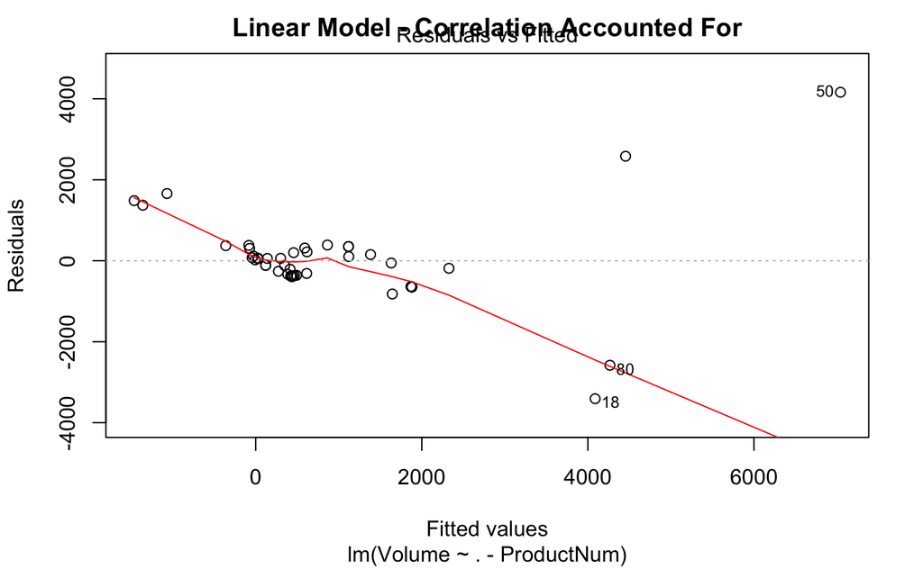

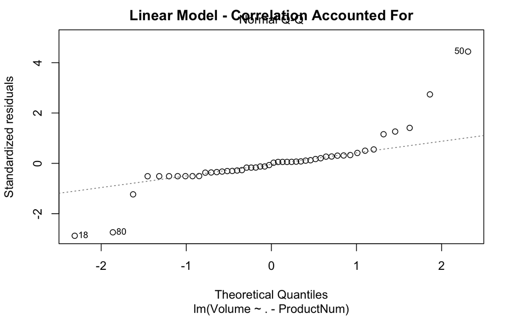

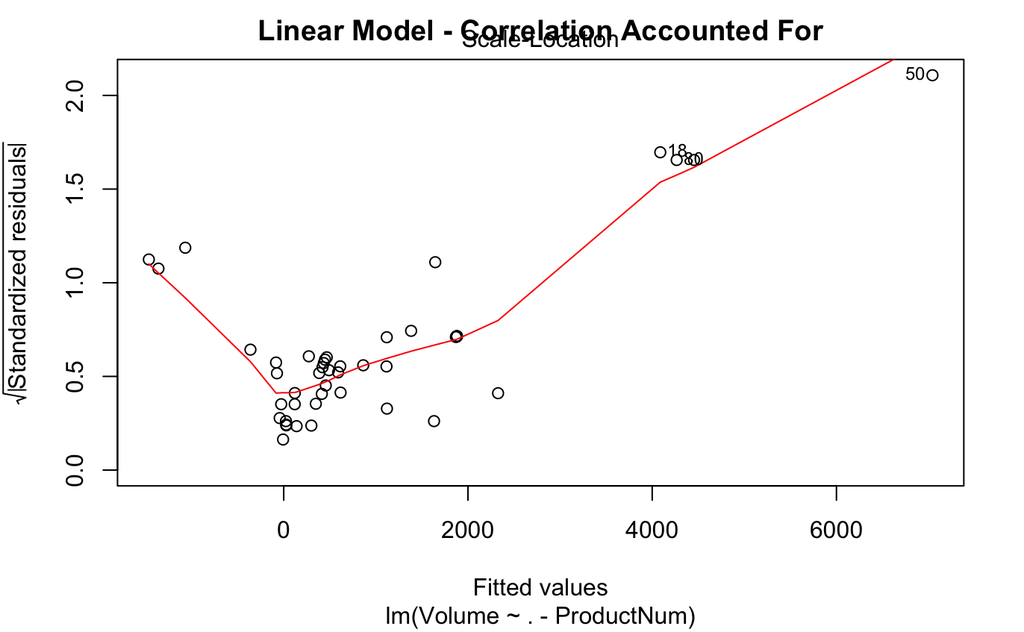

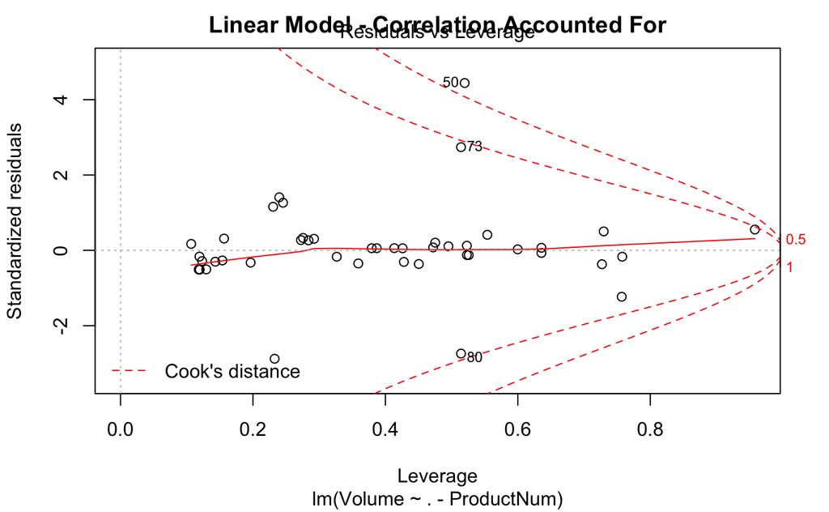

```r
plot(lm_model_after_perfect_correlation_alias_VIF2, main = "Linear Model - Correlation Accounted For")
```

This is just bad. This model is not appropriate for this dataset.

This doesn’t look very random. We have quite a bit of datapoints that are so close to the line.

#### 2.1.3.1 Linear Model: Remove Outliers

```r
# find outliers
train_data_after_correlation[train_data_after_correlation$Volume > 6000,]
```

[output not shown]

```r
train_data_after_correlation_rm_outliers <- train_data_after_correlation[!train_data_after_correlation$Volume > 6000,]
```

Let’s rerun the model without the outliers.

```r
lm_model_correlation_outliers <- lm(Volume ~ . - ProductNum, train_data_after_correlation_rm_outliers)
summary(lm_model_correlation_outliers)
plot(lm_model_correlation_outliers, main = "Model with Correlation and Outliers Accounted For")
```

[output not shown]

#### 2.1.3.2 Normalizing

```r
#normalize values
normalized_parameters <-  preProcess(train_data_after_correlation_rm_outliers, method="range")
normalized_data <- predict(normalized_parameters, train_data_after_correlation_rm_outliers)
normalized_model <-lm(Volume ~ . - ProductNum, normalized_data)
summary(normalized_model)
```

[output not shown]

Now, let’s look at p-values. If the p-value is low (usually < 0.05), the predictor is significant.

Looking at the p-values before normalizing and after, there has not been a change between what is significant and what is not.

```r
summary(normalized_model)
```

[output not shown]

Run model again, but with only significant p-values

```r
lm_model_correlation_outliers <- lm(Volume ~
                                      ProductType.GameConsole +
                                      ProductType.PC +
                                      x3StarReviews +
                                      NegativeServiceReview +
                                      Recommendproduct +
                                      BestSellersRank +
                                      ProductDepth +
                                      ProductHeight, normalized_data)
summary(lm_model_correlation_outliers)
plot(lm_model_correlation_outliers, main = "Model with Correlation, Outliers, Normalization, and P-Values, Accounted For")
```

[output not shown]

This is even worse.

Why is this happening?

What are the assumptions of multiple regression?

- There must be a linear relationship between the outcome variable and the independent variables. Scatterplots can show whether there is a linear or curvilinear relationship.
- Multivariate Normality–Multiple regression assumes that the residuals are normally distributed. – We have already seen that our residuals have not really been normally distributed. They’re not random and they fallon the fitted line a lot.
- No Multicollinearity—Multiple regression assumes that the independent variables are not highly correlated with each other. This assumption is tested using Variance Inflation Factor (VIF) values.

– We already have this issue. So many variables have high correlations with each other. - Homoscedasticity–This assumption states that the variance of error terms are similar across the values of the independent variables. A plot of standardized residuals versus predicted values can show whether points are equally distributed across all values of the independent variables.

## 2.2 Support Vector Machine (SVM)

## 2.3 Random Forest

## 2.4 Gradient Boosting

## 2.5 Compare Models

## 2.6 Select Model

# 3 Fine Tune Model

## 3.1 Feature Selection

### 3.1.1 Variable Importance

# 4 Make Predictions

## 4.1 Prepare Data

## 4.2 Apply Model

# 5 Present Results

## 5.1 Conclusions

## 5.2 Business Value

## 5.3 Recommendation to Sales Department

# 6 Lessons Learned